# Resistome data chicken1 - draft

Florentin Constancias

September 28, 2022

```r
rm(list= ls())

gc()
```

```
##          used (Mb) gc trigger (Mb) limit (Mb) max used (Mb)
## Ncells 525950 28.1    1168072 62.4         NA   669282 35.8
## Vcells 991163  7.6    8388608 64.0      16384  1839954 14.1
```

```r
require("tidyverse")
require('speedyseq')
```

```r
require(microViz)
'%!in%' <- function(x,y)!('%in%'(x,y))

source("https://raw.githubusercontent.com/fconstancias/DivComAnalyses/master/R/phyloseq_taxa_tests.R")
```

```
## Welcome to compositions, a package for compositional data analysis.
## Find an intro with "? compositions"
```

```r
source("https://raw.githubusercontent.com/fconstancias/DivComAnalyses/master/R/phyloseq_normalisation.R")
```

```r
source("https://raw.githubusercontent.com/fconstancias/DivComAnalyses/master/R/phyloseq_alpha.R")
source("https://raw.githubusercontent.com/fconstancias/DivComAnalyses/master/R/phyloseq_beta.R")
source("https://raw.githubusercontent.com/fconstancias/DivComAnalyses/master/R/phyloseq_heatmap.R")
source("https://raw.githubusercontent.com/fconstancias/DivComAnalyses/master/R/phyloseq_varia.R")
source("https://raw.githubusercontent.com/fconstancias/metabaRpipe-source/master/Rscripts/functions.R")
```

```r
export_ppt_width = NULL
export_ppt_height = NULL
# out_pptx = here::here("output/plots_ISME.pptx")
out_pptx = "~/Desktop/plots_manuscript_chicken1.pptx"
```

# Load data:

## 16S:

```r
# "data/processed/16S/ps_silva_dada2_human_chicken_all_fct_polyferms.RDS" %>%
#   here::here() %>%
#   readRDS() %>%
#   filter_taxa(function(x) sum(x > 0) > 0, TRUE) -> ps_16S
```

## resistome:

```r
"data/processed/exp1_ps_AMR.RDS" %>%
  here::here() %>%
  readRDS() -> ps_AMR
```

```r
# source("https://raw.githubusercontent.com/fconstancias/metabaRpipe-source/master/Rscripts/functions.R")
#
#   as(tax_table(ps_AMR), "matrix") %>%
#     as.data.frame() %>%
#     rownames_to_column('ASV') -> tax_table
#
#   as(otu_table(ps_AMR), "matrix") %>%
#     as.data.frame() %>%
#     rownames_to_column('ASV') -> otu_table
#
#   otu_table %>%
#     left_join(tax_table, by = c("ASV" = "ASV")) %>%
#     write_tsv("~/Desktop/TEMP/NRP72/ps_AMR.tsv")
```

## Aestetics:

```r
load( here::here("Figures/Rastetics.Rdata"))

# remove donor from legends - we better not show this guy:
treat_col <- treat_col[! treat_col %in% c('#3CB371')]
```

```r
# ps_AMR %>%
#   tax_table() %>%
#   data.frame()
```

## Others:

```r
ps_AMR %>%
  tax_table() %>%
  data.frame() %>%
  rownames_to_column("ORF_ID") -> tax_mapping
```

```r
# ps_AMR %>%
#   sample_data() %>%
#   data.frame() %>%
#   rownames_to_column("sample_id") %>%
#     # filter(Model == "Chicken") %>%
#   mutate(Day_of_Treatment_num = as.double(Day_of_Treatment)) %>%
#   # mutate(Day_of_Treatment = fct_relevel(Day_of_Treatment, c(NA, "-3", "-1", "1" , "3", "4", "5","7", "30", "47", "48")))  %>%
#   mutate(Antibiotic_mg.L = factor(Antibiotic_mg.mL, levels = c(NA, 20, 200,90, 600))) -> metadata_mapping

# metadata_mapping %>%
#   write_tsv("~/Desktop/metadata_mapping.tsv")

"data/raw/metadata_mapping_AMR.tsv" %>%
  here::here() %>%
  read_tsv() %>%
  mutate(Antibiotic_mg.L = ifelse(Phase == "Stab", NA, Antibiotic_mg.L)) %>%
  mutate(Antibiotic_mg.L = factor(Antibiotic_mg.L, levels = c(NA, 20, 200,90, 600))) -> metadata_mapping
```

No need to melt for this one since every otu is a gene with AMR hit and MGE / MAG …

```r
ps_AMR %>%
  physeq_sel_tax_table(c("PathoFact_AMR_AMR_sub_class", "PathoFact_AMR_AMR_sub_class_multi",
                         "PathoFact_AMR_Resistance_mechanism","PathoFact_AMR_Resistance_mechanism_multi",
                         "PathoFact_AMR_ARG", "PathoFact_AMR_Database", "PathoFact_AMR_MGE_prediction_clean_2",
                         "viralverify_Prediction", "isescan_type", "isescan_count_IS_contig" , "ANVIO_CONCOCT_HQ_clean", "CONCOCT_bin",
                         "GTDB_tax_CONCOCT_clean", "PathoFact_AMR_MGE_prediction_clean_2")) %>%
  subset_samples(Model == "Chicken") -> ps_AMR_all
```

```
## Note: Using an external vector in selections is ambiguous.
## ℹ Use `all_of(tax_sel)` instead of `tax_sel` to silence this message.
## ℹ See <https://tidyselect.r-lib.org/reference/faq-external-vector.html>.
```

```r
ps_AMR_all
```

```
## phyloseq-class experiment-level object
## otu_table()   OTU Table:          [ 3698 taxa and 49 samples ]:
## sample_data() Sample Data:        [ 49 samples by 39 sample variables ]:
## tax_table()   Taxonomy Table:     [ 3698 taxa by 13 taxonomic ranks ]:
## taxa are rows
```

Looks good, let’s go.

# Total Resistome :

## Abundance - sum Rnum_Gi:

```r
ps_AMR_all %>%
  # physeq_sel_tax_table(c("PathoFact_AMR_AMR_sub_class", "PathoFact_AMR_AMR_sub_class_multi", "PathoFact_AMR_ARG"))  %>%
  physeq_sel_tax_table(c("PathoFact_AMR_AMR_sub_class", "PathoFact_AMR_AMR_sub_class_multi", "PathoFact_AMR_ARG"))  %>%
  speedyseq::tax_glom(., taxrank = "PathoFact_AMR_ARG")  %>%
  filter_taxa(function(x) sum(x > 0) > 0, TRUE) %>%
  speedyseq::psmelt() %>%
  select(-Lactose_mM:-Total_SCFA_mM) %>%
  filter(Day_of_Treatment < 34 &
           !Sample %in% c("D3", "D19")) %>%
  filter(Reactor != "CR" & Model == "Chicken" | Model == "Human" & Reactor %in% c("TR1", "TR2", "TR3", "TR4", "TR5", "TR6", "CR"))  %>%
  group_by(Sample) %>%
  summarise(sum_abundance = sum(Abundance), .groups = "drop") %>%
  mutate(sum_abundance = na_if(sum_abundance, 0)) %>%
  left_join(metadata_mapping,
            by = c("Sample" = "sample_id")) %>%
  # mutate(Antibiotic_mg.mL = factor(Antibiotic_mg.mL, levels = c(NA, 20, 200,90, 600))) %>%
  ggplot(aes_string(x = "Day_of_Treatment", y = "sum_abundance", color = "Treatment", fill  = "Treatment", shape = "Antibiotic_mg.L")) + #shape = Fermentation
  geom_point(size = 2.5) +
  geom_line(linetype = 2,  size = 0.5,  aes_string(group = "interaction(Model,  Reactor_Treatment_Dose)")) +
  labs(y = "sum Rnum_Gi", x = "Day_of_Treatment") +
  scale_color_manual(name = "", values = treat_col,
                     na.value = "black") +
  scale_fill_manual(name = "", values = treat_col,
                    na.value = "black") +
  scale_shape_manual(name = "" ,values = c(15,16,18,19), na.value =  17) +
  # scale_alpha_continuous(name = "", range=c(0.6, 1), na.value =  1) +
  geom_vline(xintercept = 0, size = 0.5, linetype = 1, color = "grey60") +
  theme_light() +
  scale_y_continuous(labels=scientific) -> p1 # scale_y_continuous(labels = function(x) format(x, scientific = TRUE))
```

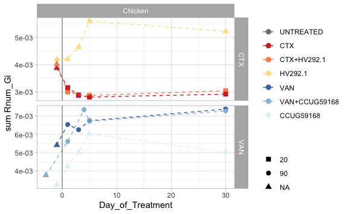

```r
p1 + facet_grid(as.formula(paste0("Antibiotic  ~  Model  ")), scales = "free", space = "fixed", drop = TRUE) -> ptmp

ptmp
```

```r
ptmp %>%
  ggsave(plot = .,bg = "transparent",scale = 2,
         units = "mm",
         dpi = 600,
         height = 0.618 * 84,
         width = 84,
         filename = "~/Desktop/Resistome_abundance.eps")

ptmp %>%
  export::graph2ppt(append = TRUE, width = 317.48031496 , height = 0.618 * 317.48031496, paper = "A4",  scaling = 2,
                    file = out_pptx)
```

```
## Exported graph as ~/Desktop/plots_manuscript_chicken1.pptx
```

Also retrieve the samples we now keep for the final analysis:

```r
p1$data %>% distinct(Sample)  %>% pull %>%  as.character() -> samples
```

Export values displayed:

```r
p1$data %>%
  select(Sample, sum_abundance, Day_of_Treatment, Treatment, Model) %>%
  arrange(Day_of_Treatment) %>%
  xlsx::write.xlsx(x = . ,
                   file = "~/Desktop/data_plots.xlsx",
                   sheetName = "resistome_abundance")
```

## / Baseline reference :

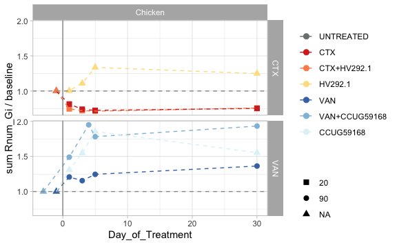

```r
#https://stackoverflow.com/questions/52581469/dynamically-normalize-all-rows-with-first-element-within-a-group
#<https://blog.exploratory.io/introducing-time-series-analysis-with-dplyr-60683587cf8a>

ps_AMR_all %>%
  physeq_sel_tax_table(c("PathoFact_AMR_AMR_sub_class", "PathoFact_AMR_AMR_sub_class_multi", "PathoFact_AMR_ARG"))  %>%
  speedyseq::tax_glom(., taxrank = "PathoFact_AMR_ARG")  %>%
  prune_samples(samples, .) %>%
  filter_taxa(function(x) sum(x > 0) > 0, TRUE) %>%
  speedyseq::psmelt() %>%
  select(-Lactose_mM:-Total_SCFA_mM) %>%
  group_by(Sample) %>%
  summarise(sum_abundance = sum(Abundance), .groups = "drop") %>%
  mutate(sum_abundance = na_if(sum_abundance, 0)) %>%
  left_join(metadata_mapping,
            by = c("Sample" = "sample_id")) %>%
  ungroup() %>%
  group_by(Model, Reactor_Treatment_Dose) %>%
  arrange(Day_of_Treatment) %>%
  mutate(per_cent_change = sum_abundance / first(sum_abundance)) %>%
  ggplot(aes_string(x = "Day_of_Treatment", y = "per_cent_change", color = "Treatment", fill  = "Treatment", shape = "Antibiotic_mg.L")) +
  geom_point(size = 2.5) +
  geom_line(linetype = 2,  size = 0.5,  aes_string(group = "interaction(Model, Reactor_Treatment_Dose)")) +
  labs(y = "sum Rnum_Gi / baseline", x = "Day_of_Treatment") +
  scale_color_manual(name = "", values = treat_col,
                     na.value = "black") +
  scale_fill_manual(name = "", values = treat_col,
                    na.value = "black") +
  scale_shape_manual(name = "" ,values = c(15,16,18,19), na.value =  17) +
  geom_vline(xintercept = 0, size = 0.5, linetype = 1, color = "grey60") +
  geom_hline(yintercept = 1, size = 0.5, linetype = 2, color = "grey60") +
  theme_light() + facet_grid(as.formula(paste0("Antibiotic ~  Model  ")),
                             scales = "free_x", space = "fixed", drop = TRUE) -> p1

p1
```

```r
p1 %>%
  ggsave(plot = .,bg = "transparent",scale = 2,
         units = "mm",
         dpi = 600,
         height = 0.618 * 84,
         width = 84,
         filename = "~/Desktop/Resistome_baseline.eps")

p1 %>%
  export::graph2ppt(append = TRUE, width = 317.48031496 / 1.25, height = 0.618 * 317.48031496  / 1.25, paper = "A4",  scaling = 2,
                    file = out_pptx)
```

```
## Exported graph as ~/Desktop/plots_manuscript_chicken1.pptx
```

Export values displayed:

```r
p1$data %>%
  data.frame() %>%
  select(Sample, per_cent_change, Day_of_Treatment, Treatment, Model) %>%
  # arrange(Day_of_Treatment) %>%
  xlsx::write.xlsx(x = . ,
                   append = TRUE,
                   file = "~/Desktop/data_plots.xlsx",
                   sheetName = "resistomebaseline")
```

# AMR drug classes

```r
ps_AMR_all %>%
  physeq_sel_tax_table(c("PathoFact_AMR_AMR_sub_class", "PathoFact_AMR_AMR_sub_class_multi", "PathoFact_AMR_ARG"))  %>%
  speedyseq::tax_glom(., taxrank = "PathoFact_AMR_AMR_sub_class_multi")  %>%
  physeq_sel_tax_table(c("PathoFact_AMR_AMR_sub_class_multi")) %>%
  prune_samples(samples, .) %>%
  filter_taxa(function(x) sum(x > 0) > 0, TRUE) %>%
  physeq_add_metadata(metadata_mapping,
                      sample_column = "sample_id") %>%
  transform_sample_counts(function(x) x/sum(x) * 100) %>%
  subset_taxa(PathoFact_AMR_AMR_sub_class_multi %!in% c("Unclassified", "multidrug (unclassified)")) %>%
  # ps_mutate(Day_of_Treatment = as.numeric(Day_of_Treatment)) %>%
  ps_arrange(Day_of_Treatment) %>%
  comp_barplot(
    palette = distinct_palette(12, pal = "kelly"),
    tax_level = "PathoFact_AMR_AMR_sub_class_multi",
    label = "Day_of_Treatment", # name an alternative variable to label axes
    n_taxa = 12, # give more taxa unique colours
    merge_other = FALSE, # split the "other" category to display alpha diversity
    bar_width = 0.9, # reduce the bar width to 70% of one row
    bar_outline_colour = "grey5",
    sample_order = "default") +#,# is the default (use NA to remove outlines)
  # facet_by = c("Model", "Antibiotic", "Antibiotic_mg.mL", "Treatment2")) +
  # group_by = c("Model", "Antibiotic", "Antibiotic_mg.mL", "Treatment2"))
  # coord_flip() +
  theme_light() +
  ylab("Proportion - %") +
  scale_y_continuous(labels=percent) +
  facet_grid(. ~ Antibiotic + Antibiotic_mg.mL + Treatment2, scales = "free", space = "free") -> p2
# facet_wrap(Model ~ Antibiotic + Antibiotic_mg.mL + Treatment2, scales = "free", ncol = 6, nrow = 4) -> p2

# # Plot them side by side with the patchwork package.
# patch <- patchwork::wrap_plots(plot_list, nrow = 1, guides = "collect")
# patch & coord_flip() # make all plots horizontal (note: use & instead of +)
```

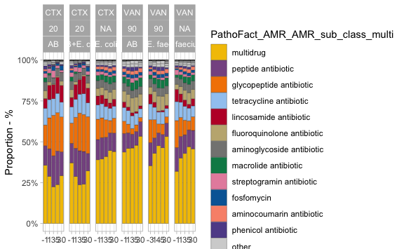

```r
plot_AMR_multi <- p2


p2
```

```r
p2 %>%
  ggsave(plot = .,bg = "transparent",scale = 2,
         units = "mm",
         dpi = 600,
         height = 0.618 * 84 * 2,
         width = 84 * 2,
         filename = "~/Desktop/Resistome_sub_class_multi_prop.eps")

p2 %>%
  export::graph2ppt(append = TRUE, width = 317.48031496 * 1.5  , height = 0.618 * 317.48031496  , paper = "A4",  scaling = 2,
                    file = out_pptx)
```

```
## Exported graph as ~/Desktop/plots_manuscript_chicken1.pptx
```

Export values displayed:

```r
p2$data %>%
  data.frame() %>%
  select(Sample, Abundance, Day_of_Treatment, Treatment, Model, OTU) %>%
  # arrange(Day_of_Treatment) %>%
  xlsx::write.xlsx(x = . ,
                   append = TRUE,
                   file = "~/Desktop/data_plots.xlsx",
                   sheetName = "drug_class")
```

same but heatmap:

```r
ps_AMR_all %>%
  physeq_sel_tax_table(c("PathoFact_AMR_AMR_sub_class_multi"))  %>%
  speedyseq::tax_glom(., taxrank = "PathoFact_AMR_AMR_sub_class_multi")  %>%
  physeq_sel_tax_table(c("PathoFact_AMR_AMR_sub_class_multi")) %>%
  prune_samples(samples, .) %>%
  filter_taxa(function(x) sum(x > 0) > 0, TRUE) %>%
  physeq_add_metadata(metadata_mapping,
                      sample_column = "sample_id") %>%
  transform_sample_counts(function(x) x/sum(x) * 100) %>%
  subset_taxa(PathoFact_AMR_AMR_sub_class_multi %!in% c("Unclassified", "multidrug (unclassified)", "MLS (unclassified)")) %>%
  # ps_mutate(Day_of_Treatment = as.numeric(Day_of_Treatment)) %>%
  # ps_arrange(-Day_of_Treatment) %>%
  speedyseq::psmelt() %>%
  # left_join(tax_mapping,
  #           by = c("Best_Hit_ARO" = "Best_Hit_ARO"),
  #           suffix = c("_x", "")) %>%
  # mutate(Sample = fct_reorder(Sample, Model,Treatment,Fermentation,Antibiotic_mg.mL, Day_of_Treatment )) %>%
  mutate(Abundance = na_if(Abundance, 0)) %>%
  mutate(logTPM = log10(Abundance + 1)) -> pheatmap_df


pheatmap_df %>%
  # replace(is.na(.), 0)  %>%
  mutate(log10Abundance = log10(Abundance)) %>%
  select(Sample, PathoFact_AMR_AMR_sub_class_multi, Abundance) %>%
  group_by(Sample, PathoFact_AMR_AMR_sub_class_multi) %>%
  pivot_wider(names_from =  Sample, PathoFact_AMR_AMR_sub_class_multi,
              values_from = Abundance) %>%
  column_to_rownames("PathoFact_AMR_AMR_sub_class_multi") -> pheatmap_samples


pheatmap_df %>%
  # replace(is.na(.), 0)  %>%
  mutate(log10Abundance = log10(Abundance)) %>%
  select(Sample, PathoFact_AMR_AMR_sub_class_multi, Abundance) %>%
  group_by(PathoFact_AMR_AMR_sub_class_multi) %>%
  summarise(meanprop = mean(Abundance, na.rm = TRUE)) -> mean_ab


# we want to knownumber of AMR gene behind each category:

ps_AMR_all %>%
  physeq_sel_tax_table(c("PathoFact_AMR_AMR_sub_class_multi", "PathoFact_AMR_ARG"))  %>%
  speedyseq::tax_glom(., taxrank = "PathoFact_AMR_ARG")  %>%
  transform_sample_counts(function(x) x/sum(x) * 100) %>%
  subset_taxa(PathoFact_AMR_AMR_sub_class_multi %!in% c("Unclassified", "multidrug (unclassified)", "MLS (unclassified)")) %>%
  # physeq_sel_tax_table(c("PathoFact_AMR_AMR_sub_class_multi")) %>%
  prune_samples(samples, .) %>%
  filter_taxa(function(x) sum(x > 0) > 0, TRUE) %>%
  physeq_add_metadata(metadata_mapping,
                      sample_column = "sample_id") %>%
  # ps_mutate(Day_of_Treatment = as.numeric(Day_of_Treatment)) %>%
  # ps_arrange(-Day_of_Treatment) %>%
  speedyseq::psmelt() %>%
  select(Sample, PathoFact_AMR_AMR_sub_class_multi, PathoFact_AMR_ARG, Abundance) %>%
  filter(Abundance > 0) %>%
  select(-Sample, -Abundance) %>%
  distinct(PathoFact_AMR_ARG, .keep_all = TRUE) %>%
  group_by(PathoFact_AMR_AMR_sub_class_multi) %>%
  summarise(nAMR = length(PathoFact_AMR_ARG)) -> num_AMR

# we want to knownumber of gene behind each AMR gene name:

ps_AMR_all %>%
  physeq_sel_tax_table(c("PathoFact_AMR_AMR_sub_class_multi", "PathoFact_AMR_ARG"))  %>%
  # speedyseq::tax_glom(., taxrank = "PathoFact_AMR_ARG")  %>%
  transform_sample_counts(function(x) x/sum(x) * 100) %>%
  subset_taxa(PathoFact_AMR_AMR_sub_class_multi %!in% c("Unclassified", "multidrug (unclassified)", "MLS (unclassified)")) %>%
  # physeq_sel_tax_table(c("PathoFact_AMR_AMR_sub_class_multi")) %>%
  prune_samples(samples, .) %>%
  filter_taxa(function(x) sum(x > 0) > 0, TRUE) %>%
  physeq_add_metadata(metadata_mapping,
                      sample_column = "sample_id") %>%
  # ps_mutate(Day_of_Treatment = as.numeric(Day_of_Treatment)) %>%
  # ps_arrange(-Day_of_Treatment) %>%
  speedyseq::psmelt() %>%
  select(Sample, PathoFact_AMR_AMR_sub_class_multi, OTU, Abundance) %>%
  filter(Abundance > 0) %>%
  select(-Sample, -Abundance) %>%
  distinct(OTU, .keep_all = TRUE) %>%
  group_by(PathoFact_AMR_AMR_sub_class_multi) %>%
  summarise(ngn = length(OTU)) -> num_gn


cbind(mean_ab,
      nGN = num_gn$ngn,
      nAMR = num_AMR$nAMR) -> row_anot
```

dendrogram gN:

```r
ps_AMR_all %>%
  physeq_sel_tax_table(c("PathoFact_AMR_AMR_sub_class_multi", "PathoFact_AMR_ARG"))  %>%
  # speedyseq::tax_glom(., taxrank = "PathoFact_AMR_ARG")  %>%
  transform_sample_counts(function(x) x/sum(x) * 100) %>%
  subset_taxa(PathoFact_AMR_AMR_sub_class_multi %!in% c("Unclassified", "multidrug (unclassified)", "MLS (unclassified)")) %>%
  # physeq_sel_tax_table(c("PathoFact_AMR_AMR_sub_class_multi")) %>%
  prune_samples(samples, .) %>%
  filter_taxa(function(x) sum(x > 0) > 0, TRUE) %>%
  physeq_add_metadata(metadata_mapping,
                      sample_column = "sample_id") %>%
  # ps_mutate(Day_of_Treatment = as.numeric(Day_of_Treatment)) %>%
  # ps_arrange(-Day_of_Treatment) %>%
  speedyseq::psmelt() %>%
  # left_join(tax_mapping,
  #           by = c("Best_Hit_ARO" = "Best_Hit_ARO"),
  #           suffix = c("_x", "")) %>%
  # mutate(Sample = fct_reorder(Sample, Model,Treatment,Fermentation,Antibiotic_mg.mL, Day_of_Treatment )) %>%
  mutate(Abundance = na_if(Abundance, 0)) %>%
  # mutate(logTPM = log10(Abundance + 1)) %>%
  # mutate(log10Abundance = log10(Abundance)) %>%
  select(Sample, OTU, Abundance) %>%
  group_by(Sample, OTU) %>%
  pivot_wider(names_from =  Sample, OTU,
              values_from = Abundance) %>%
  column_to_rownames("OTU") %>%
  replace(is.na(.), 0)  %>%
  t() %>%
  vegan::vegdist(na.rm = TRUE) %>%
  hclust(method = "ward.D2") -> clust_t_OTU
```

dendrogram AMRgN:

```r
ps_AMR_all %>%
  physeq_sel_tax_table(c("PathoFact_AMR_AMR_sub_class_multi", "PathoFact_AMR_ARG"))  %>%
  speedyseq::tax_glom(., taxrank = "PathoFact_AMR_ARG")  %>%
  transform_sample_counts(function(x) x/sum(x) * 100) %>%
  subset_taxa(PathoFact_AMR_AMR_sub_class_multi %!in% c("Unclassified", "multidrug (unclassified)", "MLS (unclassified)")) %>%
  # physeq_sel_tax_table(c("PathoFact_AMR_AMR_sub_class_multi")) %>%
  prune_samples(samples, .) %>%
  filter_taxa(function(x) sum(x > 0) > 0, TRUE) %>%
  physeq_add_metadata(metadata_mapping,
                      sample_column = "sample_id") %>%
  # ps_mutate(Day_of_Treatment = as.numeric(Day_of_Treatment)) %>%
  # ps_arrange(-Day_of_Treatment) %>%
  speedyseq::psmelt() %>%
  # left_join(tax_mapping,
  #           by = c("Best_Hit_ARO" = "Best_Hit_ARO"),
  #           suffix = c("_x", "")) %>%
  # mutate(Sample = fct_reorder(Sample, Model,Treatment,Fermentation,Antibiotic_mg.mL, Day_of_Treatment )) %>%
  mutate(Abundance = na_if(Abundance, 0)) %>%
  # mutate(logTPM = log10(Abundance + 1)) %>%
  # mutate(log10Abundance = log10(Abundance)) %>%
  select(Sample, PathoFact_AMR_ARG, Abundance) %>%
  group_by(Sample, PathoFact_AMR_ARG) %>%
  pivot_wider(names_from =  Sample, PathoFact_AMR_ARG,
              values_from = Abundance) %>%
  column_to_rownames("PathoFact_AMR_ARG") %>%
  replace(is.na(.), 0)  %>%
  t() %>%
  # sqrt() %>%
  vegan::vegdist(na.rm = TRUE, method = "robust.aitchison") %>%
  hclust(method = "ward.D2") -> clust_t_AMR

# NO : median, centroid
# "ward.D", "ward.D2", "single", "complete", "average" (= UPGMA), "mcquitty" (= WPGMA), "median" (= WPGMC) or "centroid" (= UPGMC)
```

```r
pheatmap_samples %>%
  replace(is.na(.), 0)  %>%
  t() %>%
  vegan::vegdist(na.rm = TRUE, method = "robust.aitchison") %>%
  hclust(method = "ward.D2") -> clust_t


pheatmap_samples %>%
  replace(is.na(.), 0)  %>%
  vegan::vegdist(na.rm = TRUE, method = "robust.aitchison") %>%
  # cor() %>%
  hclust(method = "ward.D2") -> clust
```

Pheatmap:

dendro class

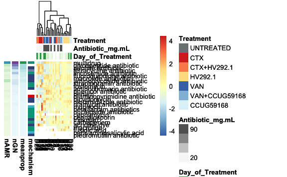

```r
pheatmap_samples %>%
  pheatmap::pheatmap(cluster_rows = FALSE ,
                     scale = "row",
                     cluster_cols = clust_t,
                     na_col = "transparent",
                     annotation_row = tax_mapping %>% rownames_to_column('tmp_col') %>%
                       filter(PathoFact_AMR_AMR_sub_class_multi %in% rownames(pheatmap_samples)) %>%
                       distinct(PathoFact_AMR_AMR_sub_class_multi, .keep_all = TRUE) %>%
                       left_join(.,
                                 row_anot,
                                 by = c("PathoFact_AMR_AMR_sub_class_multi" = "PathoFact_AMR_AMR_sub_class_multi")) %>%
                       column_to_rownames("PathoFact_AMR_AMR_sub_class_multi") %>%
                       select(PathoFact_AMR_Resistance_mechanism_multi, meanprop, nGN, nAMR) %>%
                       rename(mechanism = PathoFact_AMR_Resistance_mechanism_multi),
                     annotation_colors = list("mechanism" = resistance_type,
                                              "Treatment" = treat_col),
                     annotation_col = pheatmap_df %>%
                       select(Day_of_Treatment, Antibiotic_mg.mL, Treatment, Sample) %>%
                       mutate(Day_of_Treatment = ifelse(Day_of_Treatment < 0, NA,Day_of_Treatment)) %>%
                       distinct(Sample, .keep_all = TRUE) %>%
                       column_to_rownames("Sample"),
                     annotation_legend = TRUE)  -> p_pheat

p_pheat
```

```r
p_pheat %>%
  ggsave(plot = .,bg = "transparent",scale = 2,
         units = "mm",
         dpi = 600,
         height = 0.618 * 84 * 2,
         width = 84  * 1.5,
         filename = "~/Desktop/Resistome_heatmap_class.eps")

p_pheat %>%
  export::graph2ppt(append = TRUE, width = 317.48031496 * 8, height = 0.618 * 317.48031496 * 10 , paper = "A4",  scaling = 1,
                    file = out_pptx)
```

```
## Exported graph as ~/Desktop/plots_manuscript_chicken1.pptx
```

dendro AMR

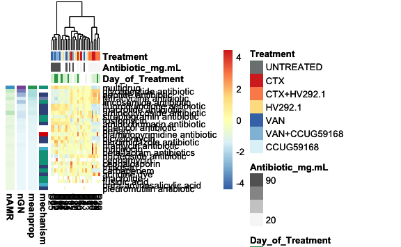

```r
pheatmap_samples %>%
  pheatmap::pheatmap(cluster_rows = FALSE ,
                     scale = "row",
                     cluster_cols = clust_t_AMR,
                     na_col = "transparent",
                     annotation_row = tax_mapping %>% rownames_to_column('tmp_col') %>%
                       filter(PathoFact_AMR_AMR_sub_class_multi %in% rownames(pheatmap_samples)) %>%
                       distinct(PathoFact_AMR_AMR_sub_class_multi, .keep_all = TRUE) %>%
                       left_join(.,
                                 row_anot,
                                 by = c("PathoFact_AMR_AMR_sub_class_multi" = "PathoFact_AMR_AMR_sub_class_multi")) %>%
                       column_to_rownames("PathoFact_AMR_AMR_sub_class_multi") %>%
                       select(PathoFact_AMR_Resistance_mechanism_multi, meanprop, nGN, nAMR) %>%
                       rename(mechanism = PathoFact_AMR_Resistance_mechanism_multi),
                     annotation_colors = list("mechanism" = resistance_type,
                                              "Treatment" = treat_col),
                     annotation_col = pheatmap_df %>%
                       select(Day_of_Treatment, Antibiotic_mg.mL, Treatment, Sample) %>%
                       mutate(Day_of_Treatment = ifelse(Day_of_Treatment < 0, NA,Day_of_Treatment)) %>%
                       distinct(Sample, .keep_all = TRUE) %>%
                       column_to_rownames("Sample"),
                     annotation_legend = TRUE)  -> p_pheat

p_pheat
```

```r
p_pheat %>%
  ggsave(plot = .,bg = "transparent",scale = 2,
         units = "mm",
         dpi = 600,
         height = 0.618 * 84 * 2,
         width = 84  * 1.5,
         filename = "~/Desktop/Resistome_heatmap_class.eps")

p_pheat %>%
  export::graph2ppt(append = TRUE, width = 317.48031496 * 8, height = 0.618 * 317.48031496 * 10 , paper = "A4",  scaling = 1,
                    file = out_pptx)
```

```
## Exported graph as ~/Desktop/plots_manuscript_chicken1.pptx
```

dendro gN

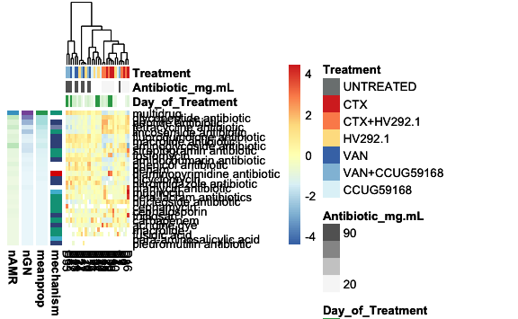

```r
pheatmap_samples %>%
  pheatmap::pheatmap(cluster_rows = FALSE ,
                     scale = "row",
                     cluster_cols = clust_t_OTU,
                     na_col = "transparent",
                     annotation_row = tax_mapping %>% rownames_to_column('tmp_col') %>%
                       filter(PathoFact_AMR_AMR_sub_class_multi %in% rownames(pheatmap_samples)) %>%
                       distinct(PathoFact_AMR_AMR_sub_class_multi, .keep_all = TRUE) %>%
                       left_join(.,
                                 row_anot,
                                 by = c("PathoFact_AMR_AMR_sub_class_multi" = "PathoFact_AMR_AMR_sub_class_multi")) %>%
                       column_to_rownames("PathoFact_AMR_AMR_sub_class_multi") %>%
                       select(PathoFact_AMR_Resistance_mechanism_multi, meanprop, nGN, nAMR) %>%
                       rename(mechanism = PathoFact_AMR_Resistance_mechanism_multi),
                     annotation_colors = list("mechanism" = resistance_type,
                                              "Treatment" = treat_col),
                     annotation_col = pheatmap_df %>%
                       select(Day_of_Treatment, Antibiotic_mg.mL, Treatment, Sample) %>%
                       mutate(Day_of_Treatment = ifelse(Day_of_Treatment < 0, NA,Day_of_Treatment)) %>%
                       distinct(Sample, .keep_all = TRUE) %>%
                       column_to_rownames("Sample"),
                     annotation_legend = TRUE)  -> p_pheat

p_pheat
```

```r
p_pheat %>%
  ggsave(plot = .,bg = "transparent",scale = 2,
         units = "mm",
         dpi = 600,
         height = 0.618 * 84 * 2,
         width = 84  * 1.5,
         filename = "~/Desktop/Resistome_heatmap_class.eps")

p_pheat %>%
  export::graph2ppt(append = TRUE, width = 317.48031496 * 8, height = 0.618 * 317.48031496 * 10 , paper = "A4",  scaling = 1,
                    file = out_pptx)
```

```
## Exported graph as ~/Desktop/plots_manuscript_chicken1.pptx
```

export underlying data:

```r
tax_mapping %>% rownames_to_column('tmp_col') %>%
  filter(PathoFact_AMR_AMR_sub_class_multi %in% rownames(pheatmap_samples)) %>%
  distinct(PathoFact_AMR_AMR_sub_class_multi, .keep_all = TRUE) %>%
  left_join(.,
            row_anot,
            by = c("PathoFact_AMR_AMR_sub_class_multi" = "PathoFact_AMR_AMR_sub_class_multi")) %>%
  column_to_rownames("PathoFact_AMR_AMR_sub_class_multi") %>%
  select(PathoFact_AMR_Resistance_mechanism_multi, meanprop, nGN, nAMR) %>%
  rename(mechanism = PathoFact_AMR_Resistance_mechanism_multi) %>%
  data.frame() %>%
  # arrange(Day_of_Treatment) %>%
  xlsx::write.xlsx(x = . ,
                   append = TRUE,
                   file = "~/Desktop/data_plots.xlsx",
                   sheetName = "drug_class_heatmap")
```

only cephalosporin:

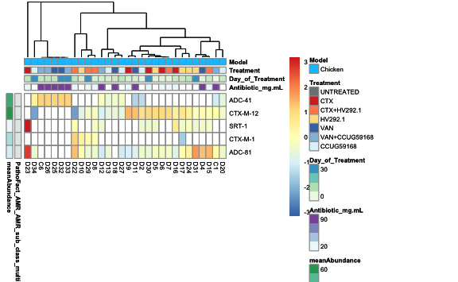

```r
ps_AMR_all %>%
  physeq_sel_tax_table(c("PathoFact_AMR_AMR_sub_class", "PathoFact_AMR_AMR_sub_class_multi", "PathoFact_AMR_ARG")) %>%
  subset_taxa(PathoFact_AMR_AMR_sub_class_multi == "cephalosporin") %>%
  speedyseq::tax_glom(., taxrank = "PathoFact_AMR_ARG")  %>%
  physeq_sel_tax_table(c("PathoFact_AMR_ARG")) %>%
  prune_samples(samples, .) %>%
  physeq_add_metadata(metadata_mapping,
                      sample_column = "sample_id") %>%
  transform_sample_counts(function(x) x/sum(x) * 100) %>%
  filter_taxa(function(x) sum(x > 0) > 0, TRUE) %>%
  # subset_taxa(PathoFact_AMR_AMR_sub_class_multi %!in% c("Unclassified", "multidrug (unclassified)", "MLS (unclassified)")) %>%
  # ps_mutate(Day_of_Treatment = as.numeric(Day_of_Treatment)) %>%
  ps_arrange(-Day_of_Treatment) %>%
  speedyseq::psmelt() %>%
  # left_join(tax_mapping,
  #           by = c("Best_Hit_ARO" = "Best_Hit_ARO"),
  #           suffix = c("_x", "")) %>%
  # mutate(Sample = fct_reorder(Sample, Model,Treatment,Fermentation,Antibiotic_mg.mL, Day_of_Treatment )) %>%
  mutate(Abundance = na_if(Abundance, 0)) %>%
  mutate(logAbundance = log10(Abundance + 1)) %>%
  mutate(PathoFact_AMR_ARG = PathoFact_AMR_ARG %>% stringr::str_trunc(45,  side ="center")) -> pheatmap_df


pheatmap_df %>%
  # replace(is.na(.), 0)  %>%
  mutate(log10Abundance = log10(Abundance)) %>%
  select(Sample, PathoFact_AMR_ARG, Abundance) %>%
  filter(Abundance > 0) %>%
  # filter(Abundance > 1) %>%
  group_by(Sample, PathoFact_AMR_ARG) %>%
  pivot_wider(names_from =  Sample, PathoFact_AMR_ARG,
              values_from = Abundance) %>%
  # mutate(PathoFact_AMR_ARG = PathoFact_AMR_ARG %>%  str_to_lower(.)) %>%
  # %>% str_to_lower(., locale = "en")
  column_to_rownames("PathoFact_AMR_ARG") -> pheatmap_samples

pheatmap_df %>%
  # replace(is.na(.), 0)  %>%
  mutate(log10Abundance = log10(Abundance)) %>%
  select(Sample, PathoFact_AMR_ARG, Abundance) %>%
  group_by(PathoFact_AMR_ARG) %>%
  summarise(meanAbundance = mean(Abundance, na.rm = TRUE)) -> mean_ab


pheatmap_samples %>%
  replace(is.na(.), 0)  %>%
  t() %>%
  vegan::vegdist(na.rm = TRUE) %>%
  hclust() -> clust_t

pheatmap_samples %>%
  replace(is.na(.), 0)  %>%
  vegan::vegdist(na.rm = TRUE, method = "euc") %>%
  # cor() %>%
  hclust() -> clust

pheatmap_samples %>%
  pheatmap::pheatmap(fontsize_col = 6,
                     fontsize = 6,
                     cluster_rows = FALSE ,
                     scale = "row",
                     cluster_cols = clust_t,
                     na_col = "transparent",
                     annotation_row = tax_mapping %>% rownames_to_column('tmp_col') %>%
                       filter(PathoFact_AMR_ARG %in% rownames(pheatmap_samples)) %>%
                       distinct(PathoFact_AMR_ARG, .keep_all = TRUE) %>%
                       left_join(.,
                                 mean_ab,
                                 by = c("PathoFact_AMR_ARG" = "PathoFact_AMR_ARG")) %>%
                       column_to_rownames("PathoFact_AMR_ARG") %>%
                       select(PathoFact_AMR_AMR_sub_class_multi, meanAbundance),
                     annotation_colors = list("PathoFact_AMR_AMR_sub_class_multi" = drug_classe_multi,
                                              "Treatment" = treat_col),
                     annotation_col = pheatmap_df %>%
                       select(Antibiotic_mg.mL,Day_of_Treatment, Treatment, Model, Sample) %>%
                       distinct(Sample, .keep_all = TRUE) %>%
                       column_to_rownames("Sample"))  -> p_pheat


p_pheat
```

```r
p_pheat %>%
  ggsave(plot = .,bg = "transparent",scale = 2,
         units = "mm",
         dpi = 600,
         height = 0.618 * 84,
         width = 84  ,
         filename = "~/Desktop/Resistome_heatmap_CTX.eps")


p_pheat %>%
  export::graph2ppt(append = TRUE, width = 317.48031496 * 2, height = 0.618 * 317.48031496 * 2 , paper = "A4",  scaling = 1,
                    file = out_pptx)
```

```
## Exported graph as ~/Desktop/plots_manuscript_chicken1.pptx
```

same but only ….:

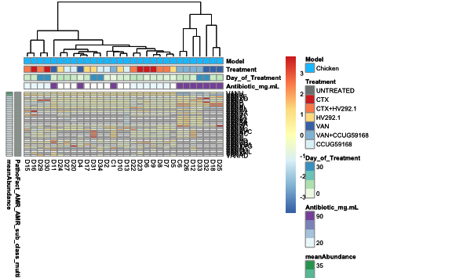

```r
ps_AMR_all %>%
  physeq_sel_tax_table(c("PathoFact_AMR_AMR_sub_class", "PathoFact_AMR_AMR_sub_class_multi", "PathoFact_AMR_ARG")) %>%
  subset_taxa(PathoFact_AMR_AMR_sub_class_multi == "glycopeptide antibiotic") %>%
  speedyseq::tax_glom(., taxrank = "PathoFact_AMR_ARG")  %>%
  physeq_sel_tax_table(c("PathoFact_AMR_ARG")) %>%
  prune_samples(samples, .) %>%
  physeq_add_metadata(metadata_mapping,
                      sample_column = "sample_id") %>%
  transform_sample_counts(function(x) x/sum(x) * 100) %>%
  filter_taxa(function(x) sum(x > 0) > 0, TRUE) %>%
  # subset_taxa(PathoFact_AMR_AMR_sub_class_multi %!in% c("Unclassified", "multidrug (unclassified)", "MLS (unclassified)")) %>%
  # ps_mutate(Day_of_Treatment = as.numeric(Day_of_Treatment)) %>%
  ps_arrange(-Day_of_Treatment) %>%
  speedyseq::psmelt() %>%
  # left_join(tax_mapping,
  #           by = c("Best_Hit_ARO" = "Best_Hit_ARO"),
  #           suffix = c("_x", "")) %>%
  # mutate(Sample = fct_reorder(Sample, Model,Treatment,Fermentation,Antibiotic_mg.mL, Day_of_Treatment )) %>%
  mutate(Abundance = na_if(Abundance, 0)) %>%
  mutate(logAbundance = log10(Abundance + 1)) %>%
  mutate(PathoFact_AMR_ARG = PathoFact_AMR_ARG %>% stringr::str_trunc(45,  side ="center")) -> pheatmap_df


pheatmap_df %>%
  # replace(is.na(.), 0)  %>%
  mutate(log10Abundance = log10(Abundance)) %>%
  select(Sample, PathoFact_AMR_ARG, Abundance) %>%
  filter(Abundance > 0) %>%
  # filter(Abundance > 1) %>%
  group_by(Sample, PathoFact_AMR_ARG) %>%
  pivot_wider(names_from =  Sample, PathoFact_AMR_ARG,
              values_from = Abundance) %>%
  # mutate(PathoFact_AMR_ARG = PathoFact_AMR_ARG %>%  str_to_lower(.)) %>%
  # %>% str_to_lower(., locale = "en")
  column_to_rownames("PathoFact_AMR_ARG") -> pheatmap_samples

pheatmap_df %>%
  # replace(is.na(.), 0)  %>%
  mutate(log10Abundance = log10(Abundance)) %>%
  select(Sample, PathoFact_AMR_ARG, Abundance) %>%
  group_by(PathoFact_AMR_ARG) %>%
  summarise(meanAbundance = mean(Abundance, na.rm = TRUE)) -> mean_ab


pheatmap_samples %>%
  replace(is.na(.), 0)  %>%
  t() %>%
  vegan::vegdist(na.rm = TRUE) %>%
  hclust() -> clust_t

pheatmap_samples %>%
  replace(is.na(.), 0)  %>%
  vegan::vegdist(na.rm = TRUE, method = "euc") %>%
  # cor() %>%
  hclust() -> clust

pheatmap_samples %>%
  pheatmap::pheatmap(fontsize_col = 6,
                     fontsize = 6,
                     cluster_rows = FALSE ,
                     scale = "row",
                     cluster_cols = clust_t,
                     na_col = "transparent",
                     annotation_row = tax_mapping %>% rownames_to_column('tmp_col') %>%
                       filter(PathoFact_AMR_ARG %in% rownames(pheatmap_samples)) %>%
                       distinct(PathoFact_AMR_ARG, .keep_all = TRUE) %>%
                       left_join(.,
                                 mean_ab,
                                 by = c("PathoFact_AMR_ARG" = "PathoFact_AMR_ARG")) %>%
                       column_to_rownames("PathoFact_AMR_ARG") %>%
                       select(PathoFact_AMR_AMR_sub_class_multi, meanAbundance),
                     annotation_colors = list("PathoFact_AMR_AMR_sub_class_multi" = drug_classe_multi,
                                              "Treatment" = treat_col),
                     annotation_col = pheatmap_df %>%
                       select(Antibiotic_mg.mL,Day_of_Treatment, Treatment, Model, Sample) %>%
                       distinct(Sample, .keep_all = TRUE) %>%
                       column_to_rownames("Sample"))  -> p_pheat


p_pheat
```

```r
p_pheat %>%
  ggsave(plot = .,bg = "transparent",scale = 2,
         units = "mm",
         dpi = 600,
         height = 0.618 * 84 * 1.5,
         width = 84  ,
         filename = "~/Desktop/Resistome_heatmap_VAN.eps")


p_pheat %>%
  export::graph2ppt(append = TRUE, width = 317.48031496 * 2, height = 0.618 * 317.48031496 * 3 , paper = "A4",  scaling = 1,
                    file = out_pptx)
```

```
## Exported graph as ~/Desktop/plots_manuscript_chicken1.pptx
```

all:

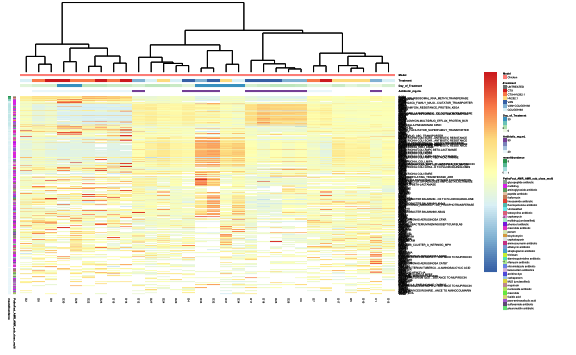

```r
ps_AMR_all %>%
  physeq_sel_tax_table(c("PathoFact_AMR_AMR_sub_class", "PathoFact_AMR_AMR_sub_class_multi", "PathoFact_AMR_ARG")) %>%
  speedyseq::tax_glom(., taxrank = "PathoFact_AMR_ARG")  %>%
  physeq_sel_tax_table(c("PathoFact_AMR_ARG")) %>%
  prune_samples(samples, .) %>%
  physeq_add_metadata(metadata_mapping,
                      sample_column = "sample_id") %>%
  transform_sample_counts(function(x) x/sum(x) * 100) %>%
  filter_taxa(function(x) sum(x > 0) > 0, TRUE) %>%
  # subset_taxa(PathoFact_AMR_AMR_sub_class_multi %!in% c("Unclassified", "multidrug (unclassified)", "MLS (unclassified)")) %>%
  # ps_mutate(Day_of_Treatment = as.numeric(Day_of_Treatment)) %>%
  ps_arrange(-Day_of_Treatment) %>%
  speedyseq::psmelt() %>%
  # left_join(tax_mapping,
  #           by = c("Best_Hit_ARO" = "Best_Hit_ARO"),
  #           suffix = c("_x", "")) %>%
  # mutate(Sample = fct_reorder(Sample, Model,Treatment,Fermentation,Antibiotic_mg.mL, Day_of_Treatment )) %>%
  mutate(Abundance = na_if(Abundance, 0)) %>%
  mutate(logAbundance = log10(Abundance + 1)) %>%
  mutate(PathoFact_AMR_ARG = PathoFact_AMR_ARG %>% stringr::str_trunc(45,  side ="center")) -> pheatmap_df


pheatmap_df %>%
  # replace(is.na(.), 0)  %>%
  mutate(log10Abundance = log10(Abundance)) %>%
  select(Sample, PathoFact_AMR_ARG, Abundance) %>%
  filter(Abundance > 0) %>%
  # filter(Abundance > 1) %>%
  group_by(Sample, PathoFact_AMR_ARG) %>%
  pivot_wider(names_from =  Sample, PathoFact_AMR_ARG,
              values_from = Abundance) %>%
  # mutate(PathoFact_AMR_ARG = PathoFact_AMR_ARG %>%  str_to_lower(.)) %>%
  # %>% str_to_lower(., locale = "en")
  column_to_rownames("PathoFact_AMR_ARG") -> pheatmap_samples

pheatmap_df %>%
  # replace(is.na(.), 0)  %>%
  mutate(log10Abundance = log10(Abundance)) %>%
  select(Sample, PathoFact_AMR_ARG, Abundance) %>%
  group_by(PathoFact_AMR_ARG) %>%
  summarise(meanAbundance = mean(Abundance, na.rm = TRUE)) -> mean_ab


pheatmap_samples %>%
  replace(is.na(.), 0)  %>%
  t() %>%
  vegan::vegdist(na.rm = TRUE) %>%
  hclust() -> clust_t

pheatmap_samples %>%
  replace(is.na(.), 0)  %>%
  vegan::vegdist(na.rm = TRUE, method = "robust.aitchison") %>%
  # cor() %>%
  hclust(method = "ward.D2") -> clust

pheatmap_samples %>%
  pheatmap::pheatmap(fontsize_col = 2,
                     fontsize = 2,
                     cluster_rows = FALSE ,
                     scale = "row",
                     cluster_cols = clust_t,
                     na_col = "transparent",
                     annotation_row = tax_mapping %>% rownames_to_column('tmp_col') %>%
                       filter(PathoFact_AMR_ARG %in% rownames(pheatmap_samples)) %>%
                       distinct(PathoFact_AMR_ARG, .keep_all = TRUE) %>%
                       left_join(.,
                                 mean_ab,
                                 by = c("PathoFact_AMR_ARG" = "PathoFact_AMR_ARG")) %>%
                       column_to_rownames("PathoFact_AMR_ARG") %>%
                       select(PathoFact_AMR_AMR_sub_class_multi, meanAbundance),
                     annotation_colors = list("PathoFact_AMR_AMR_sub_class_multi" = drug_classe_multi,
                                              "Treatment" = treat_col),
                     annotation_col = pheatmap_df %>%
                       select(Antibiotic_mg.mL,Day_of_Treatment, Treatment, Model, Sample) %>%
                       distinct(Sample, .keep_all = TRUE) %>%
                       column_to_rownames("Sample"))  -> p_pheat


p_pheat
```

```r
p_pheat %>%
  ggsave(plot = .,bg = "transparent",scale = 2,
         units = "mm",
         dpi = 600,
         height = 0.618 * 84 * 2.5,
         width = 84  * 0.5,
         filename = "~/Desktop/Resistome_heatmap_all_gn.eps")


p_pheat %>%
  export::graph2ppt(append = TRUE, width = 317.48031496 * 60, height = 0.618 * 317.48031496 * 260 , paper = "A4",  scaling = 1,
                    file = out_pptx)
```

```
## Exported graph as ~/Desktop/plots_manuscript_chicken1.pptx
```

# Beta-div resistome:

Generate a temporary phyloseq object first - containing PathoFact_AMR_ARG - which will be used for the 2 models: *TODO*: filter based on BP’s expertise? Unclassified… ?

## AMR gNs:

```r
ps_AMR_all %>%
  physeq_sel_tax_table(c("PathoFact_AMR_AMR_sub_class", "PathoFact_AMR_AMR_sub_class_multi", "PathoFact_AMR_ARG"))  %>%
  speedyseq::tax_glom(., taxrank = "PathoFact_AMR_ARG")  %>%
  filter_taxa(function(x) sum(x > 0) > 0, TRUE) %>%
  prune_samples(samples, .) %>%
  physeq_add_metadata(metadata_mapping,
                      sample_column = "sample_id") -> ps_tmp

ps_tmp
```

```
## phyloseq-class experiment-level object
## otu_table()   OTU Table:          [ 446 taxa and 30 samples ]:
## sample_data() Sample Data:        [ 30 samples by 42 sample variables ]:
## tax_table()   Taxonomy Table:     [ 446 taxa by 3 taxonomic ranks ]:
## taxa are rows
```

### Generate Aitchinson PCA:

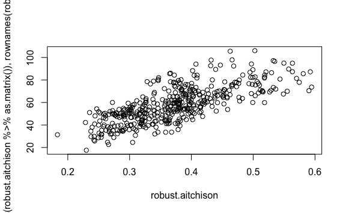

```r
ps_tmp %>%
  subset_samples(Model == "Chicken") %>%
  filter_taxa(function(x) sum(x > 0) > 0, TRUE) %>%
  # microbiome::transform(transform = "compositional") %>%
  phyloseq_plot_bdiv(dlist = NULL,
                     m = "CoDa",
                     seed = 123,
                     axis1 = 1,
                     axis2 = 2) -> coda_resistome


ps_tmp %>%
  subset_samples(Model == "Chicken") %>%
  filter_taxa(function(x) sum(x > 0) > 0, TRUE) %>%
  microbiome::transform(transform = "compositional") %>%
  speedyseq::psmelt() %>%
    pivot_wider(names_from =  Sample, PathoFact_AMR_ARG,
              values_from = Abundance) %>%
  # mutate(PathoFact_AMR_ARG = PathoFact_AMR_ARG %>%  str_to_lower(.)) %>%
  # %>% str_to_lower(., locale = "en")
  column_to_rownames("PathoFact_AMR_ARG") %>%
  t() %>%
  replace(is.na(.), 0)  %>%
  vegan::vegdist(na.rm = TRUE, method = "robust.aitchison") %>%
  magrittr::divide_by(100) -> robust.aitchison
#   # cor() %>%
#   # hclust(method = "ward.D2") -> clust
#
#
plot(
  robust.aitchison ,
  as.matrix(coda_resistome$aidist)[colnames(robust.aitchison %>% as.matrix()), rownames(robust.aitchison %>% as.matrix())] %>% as.dist()
)
```

```r
list = NULL

list$robust.aitchison <- robust.aitchison

ps_tmp %>%
  subset_samples(Model == "Chicken") %>%
  filter_taxa(function(x) sum(x > 0) > 0, TRUE) %>%
  # microbiome::transform(transform = "compositional") %>%
  phyloseq_plot_bdiv(dlist = list,
                     m = "PCoA",
                     seed = 123,
                     axis1 = 1,
                     axis2 = 2) -> robust.aitchison.pcoa
```

```
## [1] "robust.aitchison"
```

### Initial PCA:

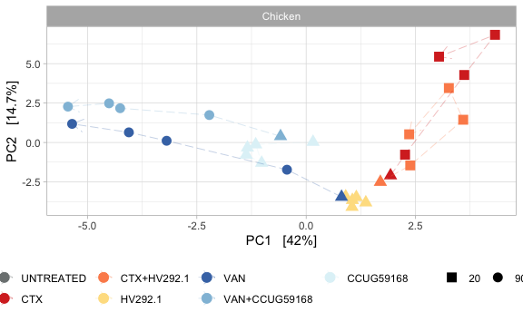

```r
coda_resistome$PCA$layers[[1]] = NULL

coda_resistome$PCA + geom_point(size= 3.5,
                                aes(colour = Treatment ,
                                    shape = Antibiotic_mg.L,
                                    alpha = NULL)) +
  geom_path(data = coda_resistome$PCA$data %>%
              arrange(Day_of_Treatment) ,
            aes(colour = Treatment, group = interaction(Model, Antibiotic, Reactor_Treatment_Dose)),
            arrow = arrow(
              angle = 30, length = unit(0.15, "inches"),
              ends = "last", type = "open"
            ), linetype = "longdash", size = 0.1) +
  theme_light() +
  scale_color_manual(name = "", values = treat_col,
                     na.value = "black") +
  scale_fill_manual(name = "", values = treat_col,
                    na.value = "black") +
  scale_shape_manual(name = "" ,values = c(15,16,18,19), na.value =  17) +
  theme(legend.position = "bottom") +
  facet_grid(. ~ Model) -> pca_treat


pca_treat
```

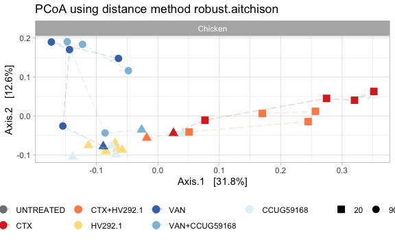

```r
robust.aitchison.pcoa$robust.aitchison$layers[[1]] = NULL
robust.aitchison.pcoa$robust.aitchison$layers[[1]] = NULL
robust.aitchison.pcoa$robust.aitchison$layers[[2]] = NULL

robust.aitchison.pcoa$robust.aitchison + geom_point(size = 3.5,
                                aes(colour = Treatment ,
                                    shape = Antibiotic_mg.L,
                                    alpha = NULL)) +
  geom_path(data = robust.aitchison.pcoa$robust.aitchison$data %>%
              arrange(Day_of_Treatment) ,
            aes(colour = Treatment, group = interaction(Model, Antibiotic, Reactor_Treatment_Dose)),
            arrow = arrow(
              angle = 30, length = unit(0.15, "inches"),
              ends = "last", type = "open"
            ), linetype = "longdash", size = 0.1) +
  theme_light() +
  scale_color_manual(name = "", values = treat_col,
                     na.value = "black") +
  scale_fill_manual(name = "", values = treat_col,
                    na.value = "black") +
  scale_shape_manual(name = "" ,values = c(15,16,18,19), na.value =  17) +
  theme(legend.position = "bottom") +
  facet_grid(. ~ Model) -> pca_treat

pca_treat
```

```r
pca_treat%>%
  ggsave(plot = .,bg = "transparent",scale = 2,
         units = "mm",
         dpi = 600,
         height = 0.618 * 84,
         width = 84,
         filename = "~/Desktop/Resistome_beta_chick.eps")

pca_treat%>%
  export::graph2ppt(append = TRUE, width = 317.48031496  , height = 0.618 * 317.48031496  , paper = "A4",  scaling = 2,
                    file = out_pptx)
```

```
## Exported graph as ~/Desktop/plots_manuscript_chicken1.pptx
```

We generate a empty plot for vectors:

```r
pca_treat +
  scale_fill_manual(values = c("transparent")) +
  scale_color_manual(values = c(rep("transparent", 6))) +
  theme(panel.border = element_blank(), panel.grid.major = element_blank(),
        panel.grid.minor = element_blank(), axis.line = element_line(colour = "black")) -> empty_plot_tmp
```

```
## which will replace the existing scale.
```

### Next, we add AM drug classes info as envfit vectors on the generated ‘empty’ plot:

```r
phyloseq_add_taxa_vector_fix(dist = list$robust.aitchison,
                             phyloseq = ps_tmp %>%
                               physeq_sel_tax_table(c("PathoFact_AMR_AMR_sub_class_multi")) %>%
                               subset_samples(Model == "Chicken") %>%
                               filter_taxa(function(x) sum(x > 0) > 0, TRUE),
                             figure_ord = empty_plot_tmp,
                             taxrank_glom = "PathoFact_AMR_AMR_sub_class_multi") -> envfit_class
envfit_class$signenvfit %>%
  mutate_if(is.numeric, ~round(., 4)) %>%
  DT::datatable()
```

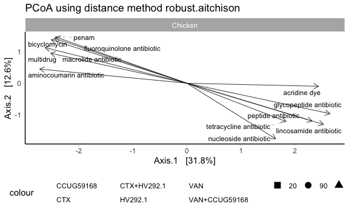

```r
envfit_class$plot
```

```r
# ppp$plot +
#   ggrepel::geom_text_repel(cex=2,
#                            aes(label= Phase),
#                            segment.color = 'black',
#                            segment.size = 0.5,
#                            ppp$plot$data %>% filter(Phase %in% c("Stab")) %>% unique()
#   ) -> pbeta

envfit_class$plot %>%
  export::graph2ppt(append = TRUE, width = 317.48031496, height = 0.618 * 317.48031496, paper = "A4",  scaling = 2,
                    file = out_pptx)
```

```
## Exported graph as ~/Desktop/plots_manuscript_chicken1.pptx
```

```r
envfit_class$plot %>%
  ggsave(plot = .,bg = "transparent",scale = 2,
         units = "mm",
         dpi = 600,
         height = 0.618 * 84,
         width = 84,
         filename = "~/Desktop/Resistome_beta_chick_class.eps")
```

### Next, we add MGE prediction genes abundance as envfit vectors on the generated ‘empty’ plot:

```r
ps_AMR_all %>%
  physeq_sel_tax_table(c("PathoFact_AMR_MGE_prediction_clean_2"))  %>%
  speedyseq::tax_glom(., taxrank = "PathoFact_AMR_MGE_prediction_clean_2") %>%
  # physeq_sel_tax_table(c("PathoFact_AMR_AMR_sub_class_multi")) %>%
  prune_samples(samples, .) %>%
  subset_samples(Model == "Chicken") %>%
  filter_taxa(function(x) sum(x > 0) > 0, TRUE) %>%
  physeq_add_metadata(metadata_mapping,
                      sample_column = "sample_id") -> ps_tmp_envfit

# custom PathoFact_AMR_MGE_prediction cleaning- should be done once at the begining...

ps_tmp_envfit %>%
  tax_table() %>%
  data.frame() %>%
  mutate(PathoFact_AMR_MGE_prediction_clean_2 = case_when(grepl("ambiguous", PathoFact_AMR_MGE_prediction_clean_2) ~ "ambiguous", TRUE ~ PathoFact_AMR_MGE_prediction_clean_2)) %>%
  mutate(PathoFact_AMR_MGE_prediction_clean_2 = case_when(PathoFact_AMR_MGE_prediction_clean_2 %in% c("MAG", "chromosome")  ~ "MAG - chromosome", TRUE ~ PathoFact_AMR_MGE_prediction_clean_2)) %>%
  as.matrix() -> tax_table(ps_tmp_envfit)

ps_tmp_envfit %>%
  phyloseq_add_taxa_vector_fix(dist = coda_resistome$aidist,
                               phyloseq = . ,
                               taxnames_rm = c("unclassified", "ambiguous"),
                               vector_color = "tomato",
                               figure_ord = empty_plot_tmp,
                               taxrank_glom = "PathoFact_AMR_MGE_prediction_clean_2") -> envfit_MGE



envfit_MGE$signenvfit %>%
  mutate_if(is.numeric, ~round(., 4)) %>%
  DT::datatable()
```

|  | Axis.1 | Axis.2 | pval | r | tax_rank_plot | pval.adj |
| --- | --- | --- | --- | --- | --- | --- |
| c1_megahit_367038_90781.91203 | -0.6636 | -0.5241 | 0.001 | 0.7149 | MAG - chromosome | 0.0013 |
| c1_megahit_148336_31385.31603 | 0.5313 | 0.5118 | 0.001 | 0.5443 | plasmid | 0.0013 |
| c1_megahit_107010_14.880 | 0.497 | 0.4279 | 0.001 | 0.4302 | phage | 0.0013 |

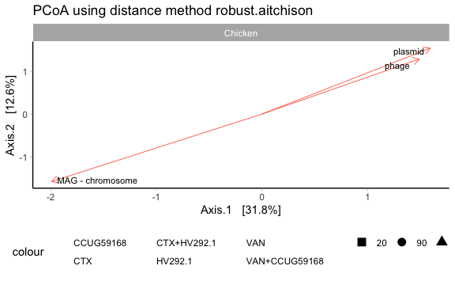

```r
envfit_MGE$plot
```

```r
# ppp$plot +
#   ggrepel::geom_text_repel(cex=2,
#                            aes(label= Phase),
#                            segment.color = 'black',
#                            segment.size = 0.5,
#                            ppp$plot$data %>% filter(Phase %in% c("Stab")) %>% unique()
#   ) -> pbeta

envfit_MGE$plot %>%
  ggsave(plot = .,bg = "transparent",scale = 2,
         units = "mm",
         dpi = 600,
         height = 0.618 * 84,
         width = 84,
         filename = "~/Desktop/Resistome_beta_chick_MGE.eps")

envfit_MGE$plot %>%
  export::graph2ppt(append = TRUE, width = 317.48031496, height = 0.618 * 317.48031496, paper = "A4",  scaling = 2,
                    file = out_pptx)
```

```
## Exported graph as ~/Desktop/plots_manuscript_chicken1.pptx
```

### Finally, we add AMR genes abunbundance as envfit vectors - similarly as before:

```r
# phyloseq_add_taxa_vector_fix(dist = coda_resistome$aidist,
#                              ggrepel_force = 30,
#                              phyloseq = ps_tmp %>%
#                                physeq_sel_tax_table(c("PathoFact_AMR_ARG")) %>%
#                                subset_samples(Model == "Chicken") %>%
#                                filter_taxa(function(x) sum(x > 0) > 0, TRUE) %>%
#                                filter_taxa(., function(x){sum(x > 0.0000001) > 3}, prune = TRUE), # only keeping dominant and occurent ones
#                              figure_ord = empty_plot_tmp,
#                              top_r = 20,
#                              vector_color = "chartreuse",
#                              taxrank_glom = "PathoFact_AMR_ARG") -> pca_env_ARG
#
# pca_env_ARG$signenvfit %>%
#   mutate_if(is.numeric, ~round(., 4)) %>%
#   DT::datatable()
```

```r
# pca_env_ARG$plot
```

```r
# pca_env_ARG$vectors
#
# pca_env_ARG$vectors %>%
#   ggsave(plot = .,bg = "transparent",scale = 2,
#          units = "mm",
#          dpi = 600,
#          height = 0.618 * 84,
#          width = 84,
#          filename = "~/Desktop/Resistome_beta_chick_ARG.eps")
#
# pca_env_ARG$vectors  %>%
#   export::graph2ppt(append = TRUE, width = 317.48031496  , height = 0.618 * 317.48031496  , paper = "A4",  scaling = 2,
#                     file = out_pptx)
```

## Gn

```r
ps_AMR_all %>%
  physeq_sel_tax_table(c("PathoFact_AMR_AMR_sub_class", "PathoFact_AMR_AMR_sub_class_multi", "PathoFact_AMR_ARG"))  %>%
  # speedyseq::tax_glom(., taxrank = "PathoFact_AMR_ARG")  %>%
  filter_taxa(function(x) sum(x > 0) > 0, TRUE) %>%
  prune_samples(samples, .) %>%
  physeq_add_metadata(metadata_mapping,
                      sample_column = "sample_id") -> ps_tmp

ps_tmp
```

```
## phyloseq-class experiment-level object
## otu_table()   OTU Table:          [ 2322 taxa and 30 samples ]:
## sample_data() Sample Data:        [ 30 samples by 42 sample variables ]:
## tax_table()   Taxonomy Table:     [ 2322 taxa by 3 taxonomic ranks ]:
## taxa are rows
```

### Generate Aitchinson PCA:

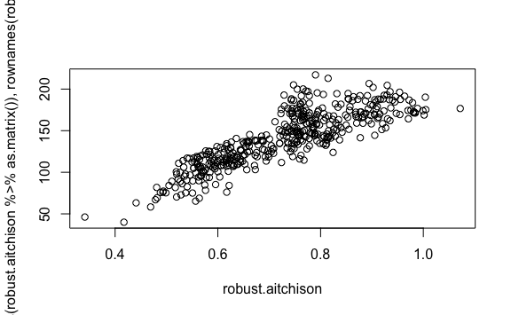

```r
ps_tmp %>%
  subset_samples(Model == "Chicken") %>%
  filter_taxa(function(x) sum(x > 0) > 0, TRUE) %>%
  # microbiome::transform(transform = "compositional") %>%
  phyloseq_plot_bdiv(dlist = NULL,
                     m = "CoDa",
                     seed = 123,
                     axis1 = 1,
                     axis2 = 2) -> coda_resistome


ps_tmp %>%
  subset_samples(Model == "Chicken") %>%
  filter_taxa(function(x) sum(x > 0) > 0, TRUE) %>%
  microbiome::transform(transform = "compositional") %>%
  speedyseq::psmelt() %>%
    pivot_wider(names_from =  Sample, OTU,
              values_from = Abundance) %>%
  # mutate(PathoFact_AMR_ARG = PathoFact_AMR_ARG %>%  str_to_lower(.)) %>%
  # %>% str_to_lower(., locale = "en")
  column_to_rownames("OTU") %>%
  t() %>%
  replace(is.na(.), 0)  %>%
  vegan::vegdist(na.rm = TRUE, method = "robust.aitchison") %>%
  magrittr::divide_by(100) -> robust.aitchison
#   # cor() %>%
#   # hclust(method = "ward.D2") -> clust
#
#
plot(
  robust.aitchison ,
  as.matrix(coda_resistome$aidist)[colnames(robust.aitchison %>% as.matrix()), rownames(robust.aitchison %>% as.matrix())] %>% as.dist()
)
```

```r
list = NULL

list$robust.aitchison <- robust.aitchison

ps_tmp %>%
  subset_samples(Model == "Chicken") %>%
  filter_taxa(function(x) sum(x > 0) > 0, TRUE) %>%
  # microbiome::transform(transform = "compositional") %>%
  phyloseq_plot_bdiv(dlist = list,
                     m = "PCoA",
                     seed = 123,
                     axis1 = 1,
                     axis2 = 2) -> robust.aitchison.pcoa
```

```
## [1] "robust.aitchison"
```

### Initial PCA:

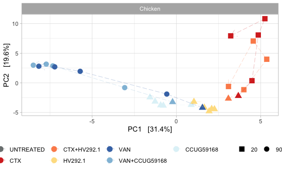

```r
coda_resistome$PCA$layers[[1]] = NULL

coda_resistome$PCA + geom_point(size= 3.5,
                                aes(colour = Treatment ,
                                    shape = Antibiotic_mg.L,
                                    alpha = NULL)) +
  geom_path(data = coda_resistome$PCA$data %>%
              arrange(Day_of_Treatment) ,
            aes(colour = Treatment, group = interaction(Model, Antibiotic, Reactor_Treatment_Dose)),
            arrow = arrow(
              angle = 30, length = unit(0.15, "inches"),
              ends = "last", type = "open"
            ), linetype = "longdash", size = 0.1) +
  theme_light() +
  scale_color_manual(name = "", values = treat_col,
                     na.value = "black") +
  scale_fill_manual(name = "", values = treat_col,
                    na.value = "black") +
  scale_shape_manual(name = "" ,values = c(15,16,18,19), na.value =  17) +
  theme(legend.position = "bottom") +
  facet_grid(. ~ Model) -> pca_treat


pca_treat
```

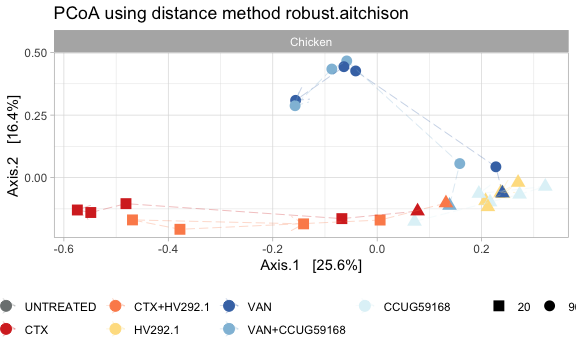

```r
robust.aitchison.pcoa$robust.aitchison$layers[[1]] = NULL
robust.aitchison.pcoa$robust.aitchison$layers[[1]] = NULL
robust.aitchison.pcoa$robust.aitchison$layers[[2]] = NULL

robust.aitchison.pcoa$robust.aitchison + geom_point(size = 3.5,
                                aes(colour = Treatment ,
                                    shape = Antibiotic_mg.L,
                                    alpha = NULL)) +
  geom_path(data = robust.aitchison.pcoa$robust.aitchison$data %>%
              arrange(Day_of_Treatment) ,
            aes(colour = Treatment, group = interaction(Model, Antibiotic, Reactor_Treatment_Dose)),
            arrow = arrow(
              angle = 30, length = unit(0.15, "inches"),
              ends = "last", type = "open"
            ), linetype = "longdash", size = 0.1) +
  theme_light() +
  scale_color_manual(name = "", values = treat_col,
                     na.value = "black") +
  scale_fill_manual(name = "", values = treat_col,
                    na.value = "black") +
  scale_shape_manual(name = "" ,values = c(15,16,18,19), na.value =  17) +
  theme(legend.position = "bottom") +
  facet_grid(. ~ Model) -> pca_treat

pca_treat
```

```r
pca_treat%>%
  ggsave(plot = .,bg = "transparent",scale = 2,
         units = "mm",
         dpi = 600,
         height = 0.618 * 84,
         width = 84,
         filename = "~/Desktop/Resistome_beta_chick_gn.eps")

pca_treat%>%
  export::graph2ppt(append = TRUE, width = 317.48031496  , height = 0.618 * 317.48031496  , paper = "A4",  scaling = 2,
                    file = out_pptx)
```

```
## Exported graph as ~/Desktop/plots_manuscript_chicken1.pptx
```

We generate a empty plot for vectors:

```r
pca_treat +
  scale_fill_manual(values = c("transparent")) +
  scale_color_manual(values = c(rep("transparent", 6))) +
  theme(panel.border = element_blank(), panel.grid.major = element_blank(),
        panel.grid.minor = element_blank(), axis.line = element_line(colour = "black")) -> empty_plot_tmp
```

```
## which will replace the existing scale.
```

### Next, we add AM drug classes info as envfit vectors on the generated ‘empty’ plot:

```r
phyloseq_add_taxa_vector_fix(dist = list$robust.aitchison,
                             phyloseq = ps_tmp %>%
                               physeq_sel_tax_table(c("PathoFact_AMR_AMR_sub_class_multi")) %>%
                               subset_samples(Model == "Chicken") %>%
                               filter_taxa(function(x) sum(x > 0) > 0, TRUE),
                             figure_ord = empty_plot_tmp,
                             taxrank_glom = "PathoFact_AMR_AMR_sub_class_multi") -> envfit_class

envfit_class$signenvfit %>%
  mutate_if(is.numeric, ~round(., 4)) %>%
  DT::datatable()
```

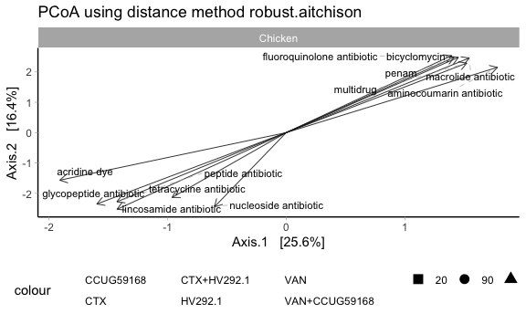

```r
envfit_class$plot
```

```r
# ppp$plot +
#   ggrepel::geom_text_repel(cex=2,
#                            aes(label= Phase),
#                            segment.color = 'black',
#                            segment.size = 0.5,
#                            ppp$plot$data %>% filter(Phase %in% c("Stab")) %>% unique()
#   ) -> pbeta

envfit_class$plot %>%
  export::graph2ppt(append = TRUE, width = 317.48031496, height = 0.618 * 317.48031496, paper = "A4",  scaling = 2,
                    file = out_pptx)
```

```
## Exported graph as ~/Desktop/plots_manuscript_chicken1.pptx
```

```r
envfit_class$plot %>%
  ggsave(plot = .,bg = "transparent",scale = 2,
         units = "mm",
         dpi = 600,
         height = 0.618 * 84,
         width = 84,
         filename = "~/Desktop/Resistome_beta_chick_class_gn.eps")
```

### Next, we add MGE prediction genes abundance as envfit vectors on the generated ‘empty’ plot:

```r
ps_AMR_all %>%
  physeq_sel_tax_table(c("PathoFact_AMR_MGE_prediction_clean_2"))  %>%
  speedyseq::tax_glom(., taxrank = "PathoFact_AMR_MGE_prediction_clean_2") %>%
  # physeq_sel_tax_table(c("PathoFact_AMR_AMR_sub_class_multi")) %>%
  prune_samples(samples, .) %>%
  subset_samples(Model == "Chicken") %>%
  filter_taxa(function(x) sum(x > 0) > 0, TRUE) %>%
  physeq_add_metadata(metadata_mapping,
                      sample_column = "sample_id") -> ps_tmp_envfit

# custom PathoFact_AMR_MGE_prediction cleaning- should be done once at the begining...

ps_tmp_envfit %>%
  tax_table() %>%
  data.frame() %>%
  mutate(PathoFact_AMR_MGE_prediction_clean_2 = case_when(grepl("ambiguous", PathoFact_AMR_MGE_prediction_clean_2) ~ "ambiguous", TRUE ~ PathoFact_AMR_MGE_prediction_clean_2)) %>%
  mutate(PathoFact_AMR_MGE_prediction_clean_2 = case_when(PathoFact_AMR_MGE_prediction_clean_2 %in% c("MAG", "chromosome")  ~ "MAG - chromosome", TRUE ~ PathoFact_AMR_MGE_prediction_clean_2)) %>%
  as.matrix() -> tax_table(ps_tmp_envfit)

ps_tmp_envfit %>%
  phyloseq_add_taxa_vector_fix(dist = coda_resistome$aidist,
                               phyloseq = . ,
                               taxnames_rm = c("unclassified", "ambiguous"),
                               vector_color = "tomato",
                               figure_ord = empty_plot_tmp,
                               taxrank_glom = "PathoFact_AMR_MGE_prediction_clean_2") -> envfit_MGE



envfit_MGE$signenvfit %>%
  mutate_if(is.numeric, ~round(., 4)) %>%
  DT::datatable()
```

|  | Axis.1 | Axis.2 | pval | r | tax_rank_plot | pval.adj |
| --- | --- | --- | --- | --- | --- | --- |
| c1_megahit_367038_90781.91203 | 0.7001 | 0.3955 | 0.001 | 0.6466 | MAG - chromosome | 0.0017 |
| c1_megahit_148336_31385.31603 | -0.5868 | -0.3794 | 0.001 | 0.4883 | plasmid | 0.0017 |
| c1_megahit_107010_14.880 | -0.5377 | -0.3141 | 0.004 | 0.3878 | phage | 0.005 |

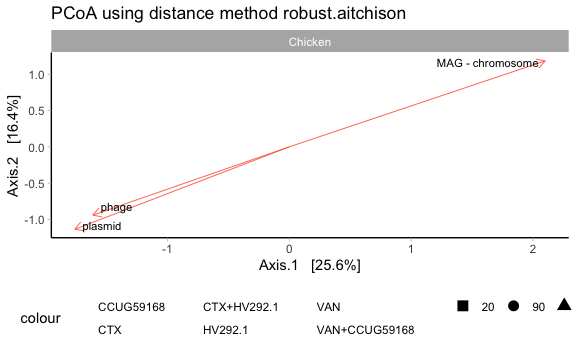

```r
envfit_MGE$plot
```

```r
# ppp$plot +
#   ggrepel::geom_text_repel(cex=2,
#                            aes(label= Phase),
#                            segment.color = 'black',
#                            segment.size = 0.5,
#                            ppp$plot$data %>% filter(Phase %in% c("Stab")) %>% unique()
#   ) -> pbeta

envfit_MGE$plot %>%
  ggsave(plot = .,bg = "transparent",scale = 2,
         units = "mm",
         dpi = 600,
         height = 0.618 * 84,
         width = 84,
         filename = "~/Desktop/Resistome_beta_chick_MGE_gn.eps")

envfit_MGE$plot %>%
  export::graph2ppt(append = TRUE, width = 317.48031496, height = 0.618 * 317.48031496, paper = "A4",  scaling = 2,
                    file = out_pptx)
```

```
## Exported graph as ~/Desktop/plots_manuscript_chicken1.pptx
```

### Finally, we add AMR genes abunbundance as envfit vectors - similarly as before:

```r
# phyloseq_add_taxa_vector_fix(dist = coda_resistome$aidist,
#                              ggrepel_force = 30,
#                              phyloseq = ps_tmp %>%
#                                physeq_sel_tax_table(c("PathoFact_AMR_ARG")) %>%
#                                subset_samples(Model == "Chicken") %>%
#                                filter_taxa(function(x) sum(x > 0) > 0, TRUE) %>%
#                                filter_taxa(., function(x){sum(x > 0.0000001) > 3}, prune = TRUE), # only keeping dominant and occurent ones
#                              figure_ord = empty_plot_tmp,
#                              top_r = 20,
#                              vector_color = "chartreuse",
#                              taxrank_glom = "PathoFact_AMR_ARG") -> pca_env_ARG
#
# pca_env_ARG$signenvfit %>%
#   mutate_if(is.numeric, ~round(., 4)) %>%
#   DT::datatable()
```

```r
# pca_env_ARG$plot
```

```r
# pca_env_ARG$vectors
#
# pca_env_ARG$vectors %>%
#   ggsave(plot = .,bg = "transparent",scale = 2,
#          units = "mm",
#          dpi = 600,
#          height = 0.618 * 84,
#          width = 84,
#          filename = "~/Desktop/Resistome_beta_chick_ARG.eps")
#
# pca_env_ARG$vectors  %>%
#   export::graph2ppt(append = TRUE, width = 317.48031496  , height = 0.618 * 317.48031496  , paper = "A4",  scaling = 2,
#                     file = out_pptx)
```

# Alpha-diversity resistome:

## gN:

```r
ps_AMR_all %>%
  physeq_sel_tax_table(c("PathoFact_AMR_AMR_sub_class", "PathoFact_AMR_AMR_sub_class_multi", "PathoFact_AMR_ARG"))  %>%
  # speedyseq::tax_glom(., taxrank = "PathoFact_AMR_ARG")  %>%
  filter_taxa(function(x) sum(x > 0) > 0, TRUE) %>%
  prune_samples(samples, .) %>%
  physeq_add_metadata(metadata_mapping,
                      sample_column = "sample_id") -> ps_tmp

ps_tmp
```

```
## phyloseq-class experiment-level object
## otu_table()   OTU Table:          [ 2322 taxa and 30 samples ]:
## sample_data() Sample Data:        [ 30 samples by 42 sample variables ]:
## tax_table()   Taxonomy Table:     [ 2322 taxa by 3 taxonomic ranks ]:
## taxa are rows
```

```r
sample_data(ps_tmp)$Read_nrom = 1000000

ps_tmp %>%
  phyloseq_density_normalize(physeq = .,
                             # sample_idx = "Reactor",
                             value_idx = "Read_nrom") %>%
  # transform_sample_counts(function(x) (x*sum(x)) *100) %>%
  phyloseq_alphas(phylo = FALSE) -> resistome_alpha
```

```
##
## microbiome R package (microbiome.github.com)
##
##
##
##  Copyright (C) 2011-2022 Leo Lahti,
##     Sudarshan Shetty et al. <microbiome.github.io>
```

```
## Observed richness
```

```
## Other forms of richness
```

```
## Diversity
```

```
## Evenness
```

```
## Dominance
```

```
## Rarity
```

```r
resistome_alpha %>%
  glimpse()
```

```
## Rows: 30
## Columns: 73
## $ id...1                      <chr> "C1", "C6", "D10", "D11", "D12", "D13", "D…
## $ sample_id                   <chr> "C1", "C6", "D10", "D11", "D12", "D13", "D…
## $ Description2                <chr> NA, NA, NA, NA, NA, NA, NA, NA, NA, NA, NA…
## $ Experiment                  <chr> "Continuous", "Continuous", "Continuous", …
## $ Reactor                     <chr> "TR5", "TR5", "TR3", "TR4", "TR5", "TR6", …
## $ Treatment                   <chr> "VAN+CCUG59168", "VAN+CCUG59168", "HV292.1…
## $ Day_of_Connection           <dbl> 13, 20, 17, 17, 17, 17, 19, 19, 19, 19, 19…
## $ Day_of_Treatment            <dbl> -3, 4, 1, 1, 1, 1, 3, 3, 3, 3, 3, 5, 5, 5,…
## $ Day_from_Inoculum           <dbl> 36, 43, 40, 40, 40, 40, 42, 42, 42, 42, 42…
## $ Enrichment                  <chr> "NotEnriched", "NotEnriched", "NotEnriched…
## $ Phase                       <chr> "Stab", "Treat", "Treat", "Treat", "Treat"…
## $ Treatment2                  <chr> "AB+E. faecium", "AB+E. faecium", "E. coli…
## $ Date                        <chr> "2020-06-24T00:00:00Z", "2020-07-01T00:00:…
```

[output cut: 60 more lines]

```r
plot_alpha_div_NRP72 <- function(df = resistome_alpha, x = "Day_of_Treatment", y = "value",  point_size = 2.5, color = "Treatment", fill  = "Treatment", shape = "Antibiotic", alpha = "Antibiotic_mg.mL", facet_formula = paste0("alphadiversiy ~  Model "), ylab = "Resistome alpha-diversity", xlab = "Days (Treatment)", measures = c("Observed", "diversity_shannon"), path_group = "interaction(Model, Reactor_Treatment_Dose)"){

  df %>%
    pivot_longer(cols = all_of(measures), values_to = "value", names_to = 'alphadiversiy', values_drop_na  = TRUE) %>%
    mutate(alphadiversiy = fct_relevel(alphadiversiy, measures)) -> df_ready

  df_ready %>%
    ggplot(aes_string(x = x, y = y, color = color, fill = fill, shape = shape, alpha = alpha)) + #shape = Fermentation
    geom_point(size = point_size) +
    geom_line(linetype = 2,  size = 0.5,  aes_string(group = path_group)) +
    labs(y = ylab, x = xlab) +
    # scale_color_manual(name = "", values = treat_col,
    #                    na.value = "black") +
    # scale_fill_manual(name = "", values = treat_col,
    #                   na.value = "black") +
    facet_grid(as.formula(facet_formula), scales = "free", space = "fixed", drop = TRUE) +
    # scale_shape_manual(name = "" ,values = antibio_shape, na.value =  17) +
    # scale_alpha_discrete(name = "", range=c(0.6, 1), na.value =  0.6) +
    geom_vline(xintercept = 0, size = 0.5, linetype = 1, color = "grey60") -> p_alpha_both

  return(p_alpha_both)
}
```

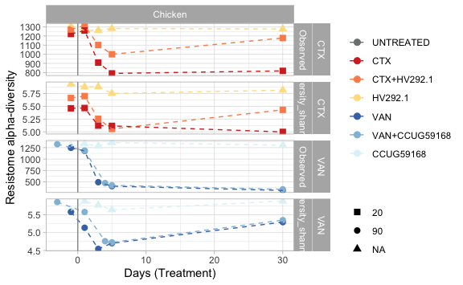

```r
resistome_alpha %>%
  plot_alpha_div_NRP72( shape = "as.factor(Antibiotic_mg.mL)", alpha = NULL) -> p_alpha

p_alpha +  scale_color_manual(name = "", values = treat_col,
                              na.value = "black") +
  scale_fill_manual(name = "", values = treat_col,
                    na.value = "black") +
  scale_shape_manual(name = "" ,values = c(15,16,18,19), na.value =  17) +
  theme_light() + facet_null() + facet_grid(Antibiotic + alphadiversiy  ~ Model, scales = "free", drop = TRUE) -> p_alpha #+
# ggh4x::facetted_pos_scales(
#   y = list(
#     alphadiversiy == "Observed" ~ scale_y_continuous(limits = c(120,270)),
#     alphadiversiy == "evenness_pielou" ~ scale_y_continuous(limits = c(0.6, 1))
#   )
# ) -> p_alpha

p_alpha
```

```r
p_alpha %>%
  ggsave(plot = .,bg = "transparent",scale = 2,
         units = "mm",
         dpi = 600,
         height = 0.618 * 84,
         width = 84,
         filename = "~/Desktop/alpha_gn.eps")

p_alpha %>%
  export::graph2ppt(append = TRUE, width = 317.48031496  , height = 0.618 * 317.48031496  , paper = "A4",  scaling = 2,
                    file = out_pptx)
```

```
## Exported graph as ~/Desktop/plots_manuscript_chicken1.pptx
```

## AMR gNs:

```r
ps_AMR_all %>%
  physeq_sel_tax_table(c("PathoFact_AMR_AMR_sub_class", "PathoFact_AMR_AMR_sub_class_multi", "PathoFact_AMR_ARG"))  %>%
  speedyseq::tax_glom(., taxrank = "PathoFact_AMR_ARG")  %>%
  filter_taxa(function(x) sum(x > 0) > 0, TRUE) %>%
  prune_samples(samples, .) %>%
  physeq_add_metadata(metadata_mapping,
                      sample_column = "sample_id") -> ps_tmp

ps_tmp
```

```
## phyloseq-class experiment-level object
## otu_table()   OTU Table:          [ 446 taxa and 30 samples ]:
## sample_data() Sample Data:        [ 30 samples by 42 sample variables ]:
## tax_table()   Taxonomy Table:     [ 446 taxa by 3 taxonomic ranks ]:
## taxa are rows
```

```r
sample_data(ps_tmp)$Read_nrom = 1000000

ps_tmp %>%
  phyloseq_density_normalize(physeq = .,
                             # sample_idx = "Reactor",
                             value_idx = "Read_nrom") %>%
  # transform_sample_counts(function(x) (x*sum(x)) *100) %>%
  phyloseq_alphas(phylo = FALSE) -> resistome_alpha
```

```
## Observed richness
```

```
## Other forms of richness
```

```
## Diversity
```

```
## Evenness
```

```
## Dominance
```

```
## Rarity
```

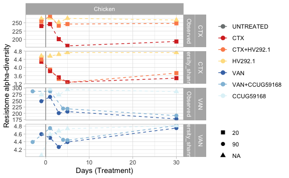

```r
resistome_alpha %>%
  plot_alpha_div_NRP72( shape = "as.factor(Antibiotic_mg.mL)", alpha = NULL) -> p_alpha

p_alpha +  scale_color_manual(name = "", values = treat_col,
                              na.value = "black") +
  scale_fill_manual(name = "", values = treat_col,
                    na.value = "black") +
  scale_shape_manual(name = "" ,values = c(15,16,18,19), na.value =  17) +
  theme_light() + facet_null() + facet_grid(Antibiotic + alphadiversiy  ~ Model, scales = "free", drop = TRUE) -> p_alpha #+
# ggh4x::facetted_pos_scales(
#   y = list(
#     alphadiversiy == "Observed" ~ scale_y_continuous(limits = c(120,270)),
#     alphadiversiy == "evenness_pielou" ~ scale_y_continuous(limits = c(0.6, 1))
#   )
# ) -> p_alpha

p_alpha
```

```r
p_alpha %>%
  ggsave(plot = .,bg = "transparent",scale = 2,
         units = "mm",
         dpi = 600,
         height = 0.618 * 84,
         width = 84,
         filename = "~/Desktop/alpha.eps")

p_alpha %>%
  export::graph2ppt(append = TRUE, width = 317.48031496  , height = 0.618 * 317.48031496  , paper = "A4",  scaling = 2,
                    file = out_pptx)
```

```
## Exported graph as ~/Desktop/plots_manuscript_chicken1.pptx
```

# MGE :

```r
ps_AMR_all %>%
  physeq_sel_tax_table(c("PathoFact_AMR_AMR_sub_class", "PathoFact_AMR_AMR_sub_class_multi", "PathoFact_AMR_ARG", "PathoFact_AMR_MGE_prediction_clean_2"))  %>%
  speedyseq::tax_glom(., taxrank = "PathoFact_AMR_MGE_prediction_clean_2")  %>%
  physeq_sel_tax_table(c("PathoFact_AMR_MGE_prediction_clean_2")) %>%
  # physeq_sel_tax_table(c("PathoFact_AMR_AMR_sub_class_multi")) %>%
  prune_samples(samples, .) %>%
  filter_taxa(function(x) sum(x > 0) > 0, TRUE) %>%
  physeq_add_metadata(metadata_mapping,
                      sample_column = "sample_id") -> ps_tmp

ps_tmp %>%
  tax_table() %>%
  data.frame() %>%
  mutate(PathoFact_AMR_MGE_prediction_clean_2 = case_when(grepl("ambiguous", PathoFact_AMR_MGE_prediction_clean_2) ~ "ambiguous", TRUE ~ PathoFact_AMR_MGE_prediction_clean_2)) %>%
  mutate(PathoFact_AMR_MGE_prediction_clean_2 = case_when(PathoFact_AMR_MGE_prediction_clean_2 %in% c("MAG", "chromosome")  ~ "MAG - chromosome", TRUE ~ PathoFact_AMR_MGE_prediction_clean_2)) %>%
  mutate(PathoFact_AMR_MGE_prediction_clean_2 = fct_relevel(PathoFact_AMR_MGE_prediction_clean_2, c("MAG", "chromosome", "plasmid", "phage", "ambiguous", "unclassified"))) %>%
  as.matrix() -> tax_table(ps_tmp)
```

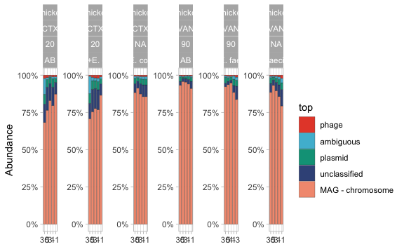

```r
ps_tmp %>%
  ps_arrange(-Day_of_Treatment) %>%
  comp_barplot(
    tax_level = "PathoFact_AMR_MGE_prediction_clean_2",
    label = "Day_of_Treatment", # name an alternative variable to label axes
    n_taxa = 20, # give more taxa unique colours
    merge_other = FALSE, # split the "other" category to display alpha diversity
    bar_width = 0.9, # reduce the bar width to 70% of one row
    bar_outline_colour = "grey5",
    sample_order = "default") +#,# is the default (use NA to remove outlines)
  # facet_by = c("Model", "Antibiotic", "Antibiotic_mg.mL", "Treatment2")) +
  # group_by = c("Model", "Antibiotic", "Antibiotic_mg.mL", "Treatment2"))
  # coord_flip() +
  theme_light() +
  scale_y_continuous(labels=percent) +
  facet_wrap(Model ~ Antibiotic + Antibiotic_mg.mL + Treatment2, scales = "free", ncol = 6, nrow = 4) -> p2
#
# # Plot them side by side with the patchwork package.
# patch <- patchwork::wrap_plots(plot_list, nrow = 1, guides = "collect")
# patch & coord_flip() # make all plots horizontal (note: use & instead of +)
#

p2 %>%
  ggpubr::set_palette("npg") -> p2
p2
```

```r
p2 %>%
  ggsave(plot = .,bg = "transparent",scale = 2,
         units = "mm",
         dpi = 600,
         height = 0.618 * 84 * 2,
         width = 84 * 2,
         filename = "~/Desktop/AMR_carrier.eps")

p2 %>%
  export::graph2ppt(append = TRUE, width = 317.48031496 * 1.5  , height = 0.618 * 317.48031496  , paper = "A4",  scaling = 2,
                    file = out_pptx)
```

```
## Exported graph as ~/Desktop/plots_manuscript_chicken1.pptx
```

using the data stored in p2 object:

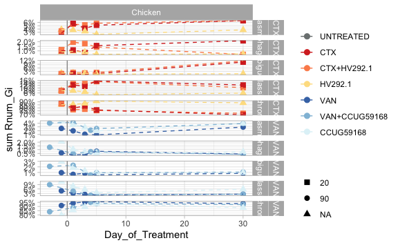

```r
p2$data %>%
  mutate(top = fct_relevel(top, c("MAG", "chromosome", "plasmid", "phage", "ambiguous", "unclassified"))) %>%
  mutate(Antibiotic_mg.mL = factor(Antibiotic_mg.mL, levels = c(NA, 20, 200,90, 600))) %>%
  ggplot(aes_string(x = "Day_of_Treatment", y = "Abundance", color = "Treatment", fill  = "Treatment", shape = "Antibiotic_mg.mL")) + #shape = Fermentation
  geom_point(size = 2.5) +
  geom_line(linetype = 2,  size = 0.5,  aes_string(group = "interaction(Model, Reactor_Treatment_Dose)")) +
  labs(y = paste0("sum Rnum_Gi ") , x = "Day_of_Treatment") +
  scale_color_manual(name = "", values = treat_col,
                     na.value = "black") +
  scale_fill_manual(name = "", values = treat_col,
                    na.value = "black") +
  scale_shape_manual(name = "" ,values = c(15,16,18,19), na.value =  17) +
  # scale_alpha_continuous(name = "", range=c(0.6, 1), na.value =  1) +
  geom_vline(xintercept = 0, size = 0.5, linetype = 1, color = "grey60") +
  theme_light() +
  facet_grid(Antibiotic + top ~ Model , scales = "free", drop = TRUE) +  scale_y_continuous(labels=percent) -> p1
p1
```

```r
# p1 %>%
#   ggpubr::set_palette("npg") -> p1

p1 %>%
  ggsave(plot = .,bg = "transparent",scale = 2,
         units = "mm",
         dpi = 600,
         height = 0.618 * 84 * 3,
         width = 84 * 2,
         filename = "~/Desktop/AMRcarrier_2.eps")

p1 %>%
  export::graph2ppt(append = TRUE, width = 317.48031496 * 2  , height = 0.618 * 317.48031496 * 3 , paper = "A4",  scaling = 2,
                    file = out_pptx)
```

```
## Exported graph as ~/Desktop/plots_manuscript_chicken1.pptx
```

```r
# ps_AMR_all %>%
#   physeq_sel_tax_table(c("PathoFact_AMR_AMR_sub_class", "PathoFact_AMR_AMR_sub_class_multi", "PathoFact_AMR_ARG", "PathoFact_AMR_MGE_prediction_clean_2"))  %>%
#   speedyseq::tax_glom(., taxrank = "PathoFact_AMR_MGE_prediction_clean_2")  %>%
#   physeq_sel_tax_table(c("PathoFact_AMR_MGE_prediction_clean_2")) %>%
#   # physeq_sel_tax_table(c("PathoFact_AMR_AMR_sub_class_multi")) %>%
#   prune_samples(samples, .) %>%
#   filter_taxa(function(x) sum(x > 0) > 0, TRUE) %>%
#   physeq_add_metadata(metadata_mapping,
#                       sample_column = "sample_id") -> ps_tmp
#
# ps_tmp %>%
#   tax_table() %>%
#   data.frame() %>%
#   mutate(PathoFact_AMR_MGE_prediction_clean_2 = case_when(grepl("ambiguous", PathoFact_AMR_MGE_prediction_clean_2) ~ "ambiguous", TRUE ~ PathoFact_AMR_MGE_prediction_clean_2)) %>%
#   # mutate(PathoFact_AMR_MGE_prediction_clean_2 = case_when(PathoFact_AMR_MGE_prediction_clean_2 %in% c("MAG", "chromosome")  ~ "MAG - chromosome", TRUE ~ PathoFact_AMR_MGE_prediction_clean_2)) %>%
#   mutate(PathoFact_AMR_MGE_prediction_clean_2 = fct_relevel(PathoFact_AMR_MGE_prediction_clean_2, c("MAG", "chromosome", "plasmid", "phage", "ambiguous", "unclassified"))) %>%
#   as.matrix() -> tax_table(ps_tmp)
#
# ps_tmp %>%
#   ps_arrange(-Day_of_Treatment) %>%
#   comp_barplot(
#     tax_level = "PathoFact_AMR_MGE_prediction_clean_2",
#     label = "Day_of_Treatment", # name an alternative variable to label axes
#     n_taxa = 20, # give more taxa unique colours
#     merge_other = FALSE, # split the "other" category to display alpha diversity
#     bar_width = 0.9, # reduce the bar width to 70% of one row
#     bar_outline_colour = "grey5",
#     sample_order = "default") +#,# is the default (use NA to remove outlines)
#   # facet_by = c("Model", "Antibiotic", "Antibiotic_mg.mL", "Treatment2")) +
#   # group_by = c("Model", "Antibiotic", "Antibiotic_mg.mL", "Treatment2"))
#   coord_flip() +  theme_light() +
#   scale_y_continuous(labels=percent) +
#   facet_wrap(Model ~ Antibiotic + Antibiotic_mg.mL + Treatment2, scales = "free", ncol = 6, nrow = 4) -> p2
#
# p_carrier_all <- p2
# # # Plot them side by side with the patchwork package.
# # patch <- patchwork::wrap_plots(plot_list, nrow = 1, guides = "collect")
# # patch & coord_flip() # make all plots horizontal (note: use & instead of +)
# #
#
# p2 %>%
#   ggpubr::set_palette("npg") -> p2
#
# p2
#
# p2 %>%
#   ggsave(plot = .,bg = "transparent",scale = 2,
#          units = "mm",
#          dpi = 600,
#          height = 0.618 * 84 * 2,
#          width = 84 * 2,
#          filename = "~/Desktop/AMR_carrier_3.eps")
#
# p2 %>%
#   export::graph2ppt(append = TRUE, width = 317.48031496 * 2  , height = 0.618 * 317.48031496 * 0.75 , paper = "A4",  scaling = 2,
#                     file = out_pptx)
```

### Fig. 2b

```r
ps_AMR_all %>%
  physeq_sel_tax_table(c("PathoFact_AMR_AMR_sub_class_multi",
                         "PathoFact_AMR_ARG"))  %>%
  # physeq_sel_tax_table(c("PathoFact_AMR_ARG"))  %>%
  speedyseq::tax_glom(., taxrank = "PathoFact_AMR_ARG")  %>%
  prune_samples(samples, .) %>%
  physeq_add_metadata(metadata_mapping,
                      sample_column = "sample_id") %>%
  filter_taxa(function(x) sum(x > 0) > 0, TRUE) %>%
  speedyseq::psmelt()  %>%
  filter(! grepl('nclassified', PathoFact_AMR_AMR_sub_class_multi)) -> df

results <- vector("list", length(df$PathoFact_AMR_AMR_sub_class_multi %>%  unique()))
names(results) = c(df$PathoFact_AMR_AMR_sub_class_multi %>%  unique())

for (dd in df$PathoFact_AMR_AMR_sub_class_multi %>%  unique())
{
  print(dd)
  df %>%
    filter(PathoFact_AMR_AMR_sub_class_multi == !!dd) %>%
    select(-Lactose_mM:-Total_SCFA_mM) %>%
    group_by(Sample, PathoFact_AMR_AMR_sub_class_multi) %>%
    summarise(sum_abundance = sum(Abundance), .groups = "drop") %>%
    mutate(sum_abundance = na_if(sum_abundance, 0)) %>%
    left_join(metadata_mapping,
              by = c("Sample" = "sample_id")) %>%
    # filter(Model == "Chicken") %>%
    # mutate(Day_of_Treatment_num = as.double(Day_of_Treatment)) %>%
    # mutate(Day_of_Treatment = fct_relevel(Day_of_Treatment, c(NA, "-3", "-1", "1" , "3", "4", "5","7", "30", "47", "48")))  %>%
    mutate(Antibiotic_mg.mL = factor(Antibiotic_mg.mL, levels = c(NA, 20, 200,90, 600))) %>%
    ggplot(aes_string(x = "Day_of_Treatment", y = "sum_abundance", color = "Treatment", fill  = "Treatment", shape = "Antibiotic_mg.mL")) + #shape = Fermentation
    geom_point(size = 2.5) +
    geom_line(linetype = 2,  size = 0.5,  aes_string(group = "interaction(Model, Reactor_Treatment_Dose)")) +
    labs(y = paste0("sum Rnum_Gi ") , x = "Day_of_Treatment") +
    scale_color_manual(name = "", values = treat_col,
                       na.value = "black") +
    scale_fill_manual(name = "", values = treat_col,
                      na.value = "black") +
    scale_shape_manual(name = "" ,values = c(15,16,18,19), na.value =  17) +
    # scale_alpha_continuous(name = "", range=c(0.6, 1), na.value =  1) +
    geom_vline(xintercept = 0, size = 0.5, linetype = 1, color = "grey60") +
    ggtitle(dd) +
    theme_light() +
    facet_grid(Antibiotic  ~ Model , scales = "free", drop = TRUE) +  scale_y_continuous(labels=scientific) -> p1
  # scale_y_continuous(labels = function(x) format(x, scientific = TRUE)) -> p1

  # p1 + facet_grid(as.formula(paste0("Antibiotic_mg.mL + PathoFact_AMR_AMR_sub_class_multi ~  Model  ")), scales = "fixed", space = "fixed", drop = TRUE)
  #
  # p1 + facet_wrap(as.formula(paste0("PathoFact_AMR_AMR_sub_class_multi ~  Model  ")),scales = "free"
  #)
  results[[dd]] <- p1


  results[[dd]]  %>%
    ggsave(plot = .,bg = "transparent",scale = 2,
           units = "mm",
           dpi = 600,
           height = 0.618 * 84,
           width = 84,
           filename = paste0("~/Desktop/AMR_class_", dd, ".eps"))

  results[[dd]]  %>%
    export::graph2ppt(append = TRUE, width = 317.48031496 , height = 0.618 * 317.48031496, paper = "A4",  scaling = 2,
                      file = out_pptx)

}
```

```
## [1] "peptide antibiotic"
```

```
## Exported graph as ~/Desktop/plots_manuscript_chicken1.pptx
```

```
## [1] "glycopeptide antibiotic"
```

```
## Exported graph as ~/Desktop/plots_manuscript_chicken1.pptx
```

```
## [1] "lincosamide antibiotic"
```

```
## Exported graph as ~/Desktop/plots_manuscript_chicken1.pptx
```

```
## [1] "tetracycline antibiotic"
```

```
## Exported graph as ~/Desktop/plots_manuscript_chicken1.pptx
```

```
## [1] "multidrug"
```

```
## Exported graph as ~/Desktop/plots_manuscript_chicken1.pptx
```

```
## [1] "macrolide antibiotic"
```

```
## Exported graph as ~/Desktop/plots_manuscript_chicken1.pptx
```

```
## [1] "aminoglycoside antibiotic"
```

```
## Exported graph as ~/Desktop/plots_manuscript_chicken1.pptx
```

```
## [1] "fluoroquinolone antibiotic"
```

```
## Exported graph as ~/Desktop/plots_manuscript_chicken1.pptx
```

```
## [1] "penam"
```

```
## Exported graph as ~/Desktop/plots_manuscript_chicken1.pptx
```

```
## [1] "fosfomycin"
```

```
## Exported graph as ~/Desktop/plots_manuscript_chicken1.pptx
```

```
## [1] "phenicol antibiotic"
```

```
## Exported graph as ~/Desktop/plots_manuscript_chicken1.pptx
```

```
## [1] "bicyclomycin"
```

```
## Exported graph as ~/Desktop/plots_manuscript_chicken1.pptx
```

```
## [1] "aminocoumarin antibiotic"
```

```
## Exported graph as ~/Desktop/plots_manuscript_chicken1.pptx
```

```
## [1] "streptogramin antibiotic"
```

```
## Exported graph as ~/Desktop/plots_manuscript_chicken1.pptx
```

```
## [1] "nitroimidazole antibiotic"
```

```
## Exported graph as ~/Desktop/plots_manuscript_chicken1.pptx
```

```
## [1] "diaminopyrimidine antibiotic"
```

```
## Exported graph as ~/Desktop/plots_manuscript_chicken1.pptx
```

```
## [1] "cephamycin"
```

```
## Exported graph as ~/Desktop/plots_manuscript_chicken1.pptx
```

```
## [1] "rifamycin antibiotic"
```

```
## Exported graph as ~/Desktop/plots_manuscript_chicken1.pptx
```

```
## [1] "beta-lactam antibiotics"
```

```
## Exported graph as ~/Desktop/plots_manuscript_chicken1.pptx
```

```
## [1] "nucleoside antibiotic"
```

```
## Exported graph as ~/Desktop/plots_manuscript_chicken1.pptx
```

```
## [1] "mupirocin"
```

```
## Exported graph as ~/Desktop/plots_manuscript_chicken1.pptx
```

```
## [1] "carbapenem"
```

```
## Exported graph as ~/Desktop/plots_manuscript_chicken1.pptx
```

```
## [1] "cephalosporin"
```

```
## Exported graph as ~/Desktop/plots_manuscript_chicken1.pptx
```

```
## [1] "triclosan"
```

```
## Exported graph as ~/Desktop/plots_manuscript_chicken1.pptx
```

```
## [1] "acridine dye"
```

```
## Exported graph as ~/Desktop/plots_manuscript_chicken1.pptx
```

```
## [1] "macrolide"
```

```
## Exported graph as ~/Desktop/plots_manuscript_chicken1.pptx
```

```
## [1] "fusidic acid"
```

```
## Exported graph as ~/Desktop/plots_manuscript_chicken1.pptx
```

```
## [1] "para-aminosalicylic acid"
```

```
## geom_path: Each group consists of only one observation. Do you need to adjust
## the group aesthetic?
```

```
## geom_path: Each group consists of only one observation. Do you need to adjust
## the group aesthetic?
## Exported graph as ~/Desktop/plots_manuscript_chicken1.pptx
```

```
## [1] "pleuromutilin antibiotic"
```

```
## geom_path: Each group consists of only one observation. Do you need to adjust
## the group aesthetic?
```

```
## geom_path: Each group consists of only one observation. Do you need to adjust
## the group aesthetic?
## Exported graph as ~/Desktop/plots_manuscript_chicken1.pptx
```

Vancomycin is a glycopeptide antibiotic used in the prophylaxis and treatment of infections caused by Gram-positive bacteria. Vancomycin inhibits the synthesis of peptidoglycan, the major component of the cell wall of gram-positive bacteria. Its mechanism of action is unusual in that it acts by binding precursors of peptidoglycan, rather than by interacting with an enzyme. -> glycopeptide antibiotic

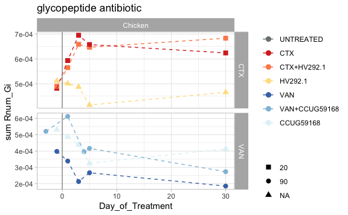

```r
results$`glycopeptide antibiotic`
```

```r
# results$`glycopeptide antibiotic` %>%
#   export::graph2ppt(append = TRUE, width = 8, height = 4,
#                     file = out_pptx)
```

Cefotaxime is a semisynthetic cephalosporin taken parenterally. It is resistant to most beta-lactamases and active against Gram-negative rods and cocci due to its aminothiazoyl and methoximino functional groups. -> cephalosporin

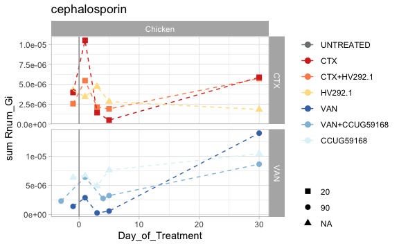

```r
results$cephalosporin
```

```r
# results$cephalosporin %>%
#   export::graph2ppt(append = TRUE, width = 8, height = 4,
#                     file = out_pptx)
```

same but normalized by baseline:

```r
# ps_AMR_all %>%
#   physeq_sel_tax_table(c("PathoFact_AMR_AMR_sub_class_multi",
#                          "PathoFact_AMR_ARG"))  %>%
#   # physeq_sel_tax_table(c("PathoFact_AMR_ARG"))  %>%
#   speedyseq::tax_glom(., taxrank = "PathoFact_AMR_ARG")  %>%
#   prune_samples(samples, .) %>%
#   physeq_add_metadata(metadata_mapping,
#                       sample_column = "sample_id") %>%
#   filter_taxa(function(x) sum(x > 0) > 0, TRUE) %>%
#   speedyseq::psmelt() %>%
#   filter(! grepl('nclassified', PathoFact_AMR_AMR_sub_class_multi)) -> df
#
# results <- vector("list", length(df$PathoFact_AMR_AMR_sub_class_multi %>%  unique()))
# names(results) = c(df$PathoFact_AMR_AMR_sub_class_multi %>%  unique())
#
# for (dd in df$PathoFact_AMR_AMR_sub_class_multi %>%  unique())
# {
#   print(dd)
#
#   df %>%
#     filter(PathoFact_AMR_AMR_sub_class_multi == !!dd) %>%
#     select(-Lactose_mM:-Total_SCFA_mM) %>%
#     group_by(Sample, PathoFact_AMR_AMR_sub_class_multi) %>%
#     summarise(sum_abundance = sum(Abundance), .groups = "drop") %>%
#     mutate(sum_abundance = na_if(sum_abundance, 0)) %>%
#     left_join(metadata_mapping,
#               by = c("Sample" = "sample_id")) %>%
#     ungroup() %>%
#     # mutate(Reactor_Treatment_Dose = paste0(Period, Reactor_Treatment_Dose)) %>%
#     group_by(Model, Fermentation,
#              Reactor_Treatment_Dose) %>%
#     arrange(Day_of_Treatment) %>%
#     mutate(per_cent_change = sum_abundance / first(sum_abundance)) %>%
#     # filter(Model == "Chicken") %>%
#     # mutate(Day_of_Treatment_num = as.double(Day_of_Treatment)) %>%
#     # mutate(Day_of_Treatment = fct_relevel(Day_of_Treatment, c(NA, "-3", "-1", "1" , "3", "4", "5","7", "30", "47", "48")))  %>%
#     mutate(Antibiotic_mg.mL = factor(Antibiotic_mg.mL, levels = c(NA, 20, 200,90, 600))) %>%
#     ggplot(aes_string(x = "Day_of_Treatment", y = "per_cent_change", color = "Treatment", fill  = "Treatment", shape = "Antibiotic_mg.mL")) + #shape = Fermentation
#     geom_point(size = 2.5) +
#     geom_line(linetype = 2,  size = 0.5,  aes_string(group = "interaction(Model, Reactor_Treatment_Dose)")) +
#     labs(y = paste0("sum Rnum_Gi / baseline ") , x = "Day_of_Treatment") +
#     scale_color_manual(name = "", values = treat_col,
#                        na.value = "black") +
#     scale_fill_manual(name = "", values = treat_col,
#                       na.value = "black") +
#     scale_shape_manual(name = "" ,values = c(15,16,18,19), na.value =  17) +
#     # scale_alpha_continuous(name = "", range=c(0.6, 1), na.value =  1) +
#     geom_vline(xintercept = 0, size = 0.5, linetype = 1, color = "grey60") +
#     ggtitle(dd) +
#     theme_light() +
#     facet_grid(Antibiotic  ~ Model , scales = "free_x", drop = TRUE) -> p1
#   # scale_y_continuous(labels = function(x) format(x, scientific = TRUE)) -> p1
#
#   # p1 + facet_grid(as.formula(paste0("Antibiotic_mg.mL + PathoFact_AMR_AMR_sub_class_multi ~  Model  ")), scales = "fixed", space = "fixed", drop = TRUE)
#   #
#   # p1 + facet_wrap(as.formula(paste0("PathoFact_AMR_AMR_sub_class_multi ~  Model  ")),scales = "free"
#   #)
#   results[[dd]] <- p1
#
#
#   results[[dd]]  %>%
#     ggsave(plot = .,bg = "transparent",scale = 2,
#            units = "mm",
#            dpi = 600,
#            height = 0.618 * 84,
#            width = 84,
#            filename = paste0("~/Desktop/AMR_class_", dd, "_baseline.eps"))
#
#   results[[dd]]  %>%
#     export::graph2ppt(append = TRUE, width = 317.48031496 , height = 0.618 * 317.48031496, paper = "A4",  scaling = 2,
#                       file = out_pptx)
#
# }
```

Vancomycin is a glycopeptide antibiotic used in the prophylaxis and treatment of infections caused by Gram-positive bacteria. Vancomycin inhibits the synthesis of peptidoglycan, the major component of the cell wall of gram-positive bacteria. Its mechanism of action is unusual in that it acts by binding precursors of peptidoglycan, rather than by interacting with an enzyme. -> glycopeptide antibiotic

```r
# results$`glycopeptide antibiotic`

# results$`glycopeptide antibiotic` %>%
#   export::graph2ppt(append = TRUE, width = 8, height = 4,
#                     file = out_pptx)
```

Cefotaxime is a semisynthetic cephalosporin taken parenterally. It is resistant to most beta-lactamases and active against Gram-negative rods and cocci due to its aminothiazoyl and methoximino functional groups. -> cephalosporin

```r
# results$cephalosporin

# results$cephalosporin %>%
#   export::graph2ppt(append = TRUE, width = 8, height = 4,
#                     file = out_pptx)
```

- line plot MAG-Chrosmosome - Plasmid - phage - unknown facet | quant & %

– quant

```r
# ps_AMR_all %>%
#   physeq_sel_tax_table(c("PathoFact_AMR_AMR_sub_class_multi",
#                          "PathoFact_AMR_MGE_prediction_clean_2",
#                          "PathoFact_AMR_ARG"))  %>%
#   # physeq_sel_tax_table(c("PathoFact_AMR_ARG"))  %>%
#   speedyseq::tax_glom(., taxrank = "PathoFact_AMR_ARG")  %>%
#   physeq_sel_tax_table(c("PathoFact_AMR_AMR_sub_class_multi",
#                          "PathoFact_AMR_ARG",
#                          "PathoFact_AMR_MGE_prediction_clean_2"))  %>%
#   speedyseq::tax_glom(., taxrank = "PathoFact_AMR_MGE_prediction_clean_2")  %>%
#   prune_samples(samples, .) %>%
#   physeq_add_metadata(metadata_mapping,
#                       sample_column = "sample_id") %>%
#   filter_taxa(function(x) sum(x > 0) > 0, TRUE) %>%
#   speedyseq::psmelt() %>%
#   filter(!grepl('nclassified', PathoFact_AMR_AMR_sub_class_multi))  -> df
#
# results <- vector("list", length(df$PathoFact_AMR_AMR_sub_class_multi %>%  unique()))
# names(results) = c(df$PathoFact_AMR_AMR_sub_class_multi %>%  unique())
#
# for (dd in df %>% filter(PathoFact_AMR_AMR_sub_class_multi != "pleuromutilin antibiotic") %>% pull(PathoFact_AMR_AMR_sub_class_multi) %>%  unique()
# ){
#
#   print(dd)
#
#   df %>%
#     filter(PathoFact_AMR_AMR_sub_class_multi == !!dd) %>%
#     select(-Lactose_mM:-Total_SCFA_mM) %>%
#     mutate(PathoFact_AMR_MGE_prediction_clean_2 = case_when(PathoFact_AMR_MGE_prediction_clean_2 %in% c("MAG", "chromosome")  ~ "MAG - chromosome", TRUE ~ PathoFact_AMR_MGE_prediction_clean_2)) %>%
#     mutate(PathoFact_AMR_MGE_prediction_clean_2 = fct_relevel(PathoFact_AMR_MGE_prediction_clean_2, c("MAG - chromosome", "plasmid", "phage", "ambiguous", "unclassified"))) %>%
#     group_by(Sample, PathoFact_AMR_MGE_prediction_clean_2, PathoFact_AMR_AMR_sub_class_multi) %>%
#     summarise(sum_abundance = sum(Abundance), .groups = "drop") %>%
#     mutate(sum_abundance = na_if(sum_abundance, 0)) %>%
#     left_join(metadata_mapping,
#               by = c("Sample" = "sample_id")) %>%
#     filter(! PathoFact_AMR_MGE_prediction_clean_2  %in% c("unclassified", "ambiguous")) %>%
#     # filter(Model == "Chicken") %>%
#     # mutate(Day_of_Treatment_num = as.double(Day_of_Treatment)) %>%
#     # mutate(Day_of_Treatment = fct_relevel(Day_of_Treatment, c(NA, "-3", "-1", "1" , "3", "4", "5","7", "30", "47", "48")))  %>%
#     mutate(Antibiotic_mg.mL = factor(Antibiotic_mg.mL, levels = c(NA, 20, 200,90, 600))) %>%
#     ggplot(aes_string(x = "Day_of_Treatment", y = "sum_abundance", color = "Treatment", fill  = "Treatment", shape = "Antibiotic_mg.mL")) + #shape = Fermentation
#     geom_point(size = 2.5) +
#     geom_line(linetype = 2,  size = 0.5,  aes_string(group = "interaction(Model, Reactor_Treatment_Dose)")) +
#     labs(y = paste0("sum Rnum_Gi ") , x = "Day_of_Treatment") +
#     scale_color_manual(name = "", values = treat_col,
#                        na.value = "black") +
#     scale_fill_manual(name = "", values = treat_col,
#                       na.value = "black") +
#     scale_shape_manual(name = "" ,values = c(15,16,18,19), na.value =  17) +
#     # scale_alpha_continuous(name = "", range=c(0.6, 1), na.value =  1) +
#     geom_vline(xintercept = 0, size = 0.5, linetype = 1, color = "grey60") +
#     ggtitle(dd) +
#     theme_light() +
#     facet_grid(Antibiotic + PathoFact_AMR_MGE_prediction_clean_2 ~ Model, scales = "free", drop = TRUE) +  scale_y_continuous(labels=scientific) -> p1
#
#   # p1 + facet_grid(as.formula(paste0("Antibiotic_mg.mL + PathoFact_AMR_AMR_sub_class_multi ~  Model  ")), scales = "fixed", space = "fixed", drop = TRUE)
#   #
#   # p1 + facet_wrap(as.formula(paste0("PathoFact_AMR_AMR_sub_class_multi ~  Model  ")),scales = "free"
#   #)
#   results[[dd]] <- p1
#
#   results[[dd]]  %>%
#     ggsave(plot = .,bg = "transparent",scale = 2,
#            units = "mm",
#            dpi = 600,
#            height = 0.618 * 84 * 1.5,
#            width = 84,
#            filename = paste0("~/Desktop/lineplot_", dd, ".eps"))
#
#   results[[dd]]  %>%
#     export::graph2ppt(append = TRUE, width = 317.48031496 , height = 0.618 * 317.48031496, paper = "A4",  scaling = 2,
#                       file = out_pptx)
#
# }
```

– then %

```r
# ps_AMR_all %>%
#   physeq_sel_tax_table(c("PathoFact_AMR_AMR_sub_class_multi",
#                          "PathoFact_AMR_MGE_prediction_clean_2",
#                          "PathoFact_AMR_ARG"))  %>%
#   # physeq_sel_tax_table(c("PathoFact_AMR_ARG"))  %>%
#   speedyseq::tax_glom(., taxrank = "PathoFact_AMR_ARG")  %>%
#   physeq_sel_tax_table(c("PathoFact_AMR_AMR_sub_class_multi",
#                          "PathoFact_AMR_ARG",
#                          "PathoFact_AMR_MGE_prediction_clean_2"))  %>%
#   speedyseq::tax_glom(., taxrank = "PathoFact_AMR_MGE_prediction_clean_2")  %>%
#   prune_samples(samples, .) %>%
#   physeq_add_metadata(metadata_mapping,
#                       sample_column = "sample_id") %>%
#   filter_taxa(function(x) sum(x > 0) > 0, TRUE) %>%
#   speedyseq::psmelt() %>%
#   select(-Lactose_mM:-Total_SCFA_mM) %>%
#   mutate(PathoFact_AMR_MGE_prediction_clean_2 = case_when(PathoFact_AMR_MGE_prediction_clean_2 %in% c("MAG", "chromosome")  ~ "MAG - chromosome", TRUE ~ PathoFact_AMR_MGE_prediction_clean_2)) %>%
#   mutate(PathoFact_AMR_MGE_prediction_clean_2 = fct_relevel(PathoFact_AMR_MGE_prediction_clean_2, c("MAG - chromosome", "plasmid", "phage", "ambiguous", "unclassified"))) -> df  #%>%
# # filter(grepl('unclassified', PathoFact_AMR_AMR_sub_class_multi))  -> df
#
# results <- vector("list", length(df$PathoFact_AMR_AMR_sub_class_multi %>%  unique()))
# names(results) = c(df$PathoFact_AMR_AMR_sub_class_multi %>%  unique())
#
# for (dd in df %>% filter(PathoFact_AMR_AMR_sub_class_multi %!in% c("pleuromutilin antibiotic", "MLS (unclassified)", "Unclassified", "multidrug (unclassified)")) %>% pull(PathoFact_AMR_AMR_sub_class_multi) %>%  unique()
# )
# {
#   print(dd)
#
#   df %>%
#     filter(PathoFact_AMR_AMR_sub_class_multi == !!dd) %>%
#     select(Sample, PathoFact_AMR_AMR_sub_class_multi, PathoFact_AMR_MGE_prediction_clean_2, Abundance) %>%
#     group_by(PathoFact_AMR_AMR_sub_class_multi, PathoFact_AMR_MGE_prediction_clean_2, Sample) -> df_tmp
#
#   df_tmp %>%
#     summarise(sum_MGE = sum(Abundance), .groups = "drop") %>%
#     mutate(sum_MGE = na_if(sum_MGE, 0)) -> df_MGE_sum
#
#   df_tmp %>%
#     group_by(Sample) %>%
#     summarise(sample_sum = sum(Abundance), .groups = "drop") %>%
#     mutate(sample_sum = na_if(sample_sum, 0)) -> df_sample_sum
#
#   df_MGE_sum %>%
#     left_join(df_sample_sum,
#               by = c("Sample" = "Sample")) %>%
#     mutate(percent_MGE = sum_MGE / sample_sum) %>%
#     # left_join()
#     left_join(metadata_mapping,
#               by = c("Sample" = "sample_id")) %>%
#     filter(! PathoFact_AMR_MGE_prediction_clean_2  %in% c("unclassified", "ambiguous")) %>%
#     # filter(Model == "Chicken") %>%
#     # mutate(Day_of_Treatment_num = as.double(Day_of_Treatment)) %>%
#     # mutate(Day_of_Treatment = fct_relevel(Day_of_Treatment, c(NA, "-3", "-1", "1" , "3", "4", "5","7", "30", "47", "48")))  %>%
#     mutate(Antibiotic_mg.mL = factor(Antibiotic_mg.mL, levels = c(NA, 20, 200,90, 600))) %>%
#     ggplot(aes_string(x = "Day_of_Treatment", y = "percent_MGE", color = "Treatment", fill  = "Treatment", shape = "Antibiotic_mg.mL")) + #shape = Fermentation
#     geom_point(size = 2.5) +
#     geom_line(linetype = 2,  size = 0.5,  aes_string(group = "interaction(Model, Reactor_Treatment_Dose)")) +
#     labs(y = paste0(" proportion % ") , x = "Day_of_Treatment") +
#     scale_color_manual(name = "", values = treat_col,
#                        na.value = "black") +
#     scale_fill_manual(name = "", values = treat_col,
#                       na.value = "black") +
#     scale_shape_manual(name = "" ,values = c(15,16,18,19), na.value =  17) +
#     # scale_alpha_continuous(name = "", range=c(0.6, 1), na.value =  1) +
#     geom_vline(xintercept = 0, size = 0.5, linetype = 1, color = "grey60") +
#     ggtitle(dd) +
#     theme_light() +
#     facet_grid(Antibiotic + PathoFact_AMR_MGE_prediction_clean_2 ~ Model, scales = "free", drop = TRUE) +  scale_y_continuous(labels=percent) -> p1
#   # scale_y_continuous(labels = function(x) format(x, scientific = TRUE)) -> p1
#
#   # p1 + facet_grid(as.formula(paste0("Antibiotic_mg.mL + PathoFact_AMR_AMR_sub_class_multi ~  Model  ")), scales = "fixed", space = "fixed", drop = TRUE)
#   #
#   # p1 + facet_wrap(as.formula(paste0("PathoFact_AMR_AMR_sub_class_multi ~  Model  ")),scales = "free"
#   #)
#   results[[dd]] <- p1
#
#
#   results[[dd]]  %>%
#     ggsave(plot = .,bg = "transparent",scale = 2,
#            units = "mm",
#            dpi = 600,
#            height = 0.618 * 84 * 1.5,
#            width = 84,
#            filename = paste0("~/Desktop/lineplot_", dd, "_percent.eps"))
#
#   results[[dd]]  %>%
#     export::graph2ppt(append = TRUE, width = 317.48031496 , height = 0.618 * 317.48031496, paper = "A4",  scaling = 2,
#                       file = out_pptx)
#
# }
```

and then baseline ratio.

```r
# ps_AMR_all %>%
#   physeq_sel_tax_table(c("PathoFact_AMR_AMR_sub_class_multi",
#                          "PathoFact_AMR_MGE_prediction_clean_2",
#                          "PathoFact_AMR_ARG"))  %>%
#   # physeq_sel_tax_table(c("PathoFact_AMR_ARG"))  %>%
#   speedyseq::tax_glom(., taxrank = "PathoFact_AMR_ARG")  %>%
#   physeq_sel_tax_table(c("PathoFact_AMR_AMR_sub_class_multi",
#                          "PathoFact_AMR_ARG",
#                          "PathoFact_AMR_MGE_prediction_clean_2"))  %>%
#   speedyseq::tax_glom(., taxrank = "PathoFact_AMR_MGE_prediction_clean_2")  %>%
#   prune_samples(samples, .) %>%
#   physeq_add_metadata(metadata_mapping,
#                       sample_column = "sample_id") %>%
#   filter_taxa(function(x) sum(x > 0) > 0, TRUE) %>%
#   speedyseq::psmelt() %>%
#   filter(! grepl('nclassified', PathoFact_AMR_AMR_sub_class_multi))  -> df
#
# results <- vector("list", length(df$PathoFact_AMR_AMR_sub_class_multi %>%  unique()))
# names(results) = c(df$PathoFact_AMR_AMR_sub_class_multi %>%  unique())
#
# for (dd in df %>% filter(PathoFact_AMR_AMR_sub_class_multi != "pleuromutilin antibiotic") %>% pull(PathoFact_AMR_AMR_sub_class_multi) %>%  unique()
# )
# {
#   print(dd)
#
#   df %>%
#     filter(PathoFact_AMR_AMR_sub_class_multi == !!dd) %>%
#     select(-Lactose_mM:-Total_SCFA_mM) %>%
#     mutate(PathoFact_AMR_MGE_prediction_clean_2 = case_when(PathoFact_AMR_MGE_prediction_clean_2 %in% c("MAG", "chromosome")  ~ "MAG - chromosome", TRUE ~ PathoFact_AMR_MGE_prediction_clean_2)) %>%
#     mutate(PathoFact_AMR_MGE_prediction_clean_2 = fct_relevel(PathoFact_AMR_MGE_prediction_clean_2, c("MAG - chromosome", "plasmid", "phage", "ambiguous", "unclassified"))) %>%
#     group_by(Sample, PathoFact_AMR_AMR_sub_class_multi, PathoFact_AMR_MGE_prediction_clean_2) %>%
#     summarise(sum_abundance = sum(Abundance), .groups = "drop") %>%
#     mutate(sum_abundance = na_if(sum_abundance, 0)) %>%
#     ungroup() %>%
#     left_join(metadata_mapping,
#               by = c("Sample" = "sample_id")) %>%
#     filter(! PathoFact_AMR_MGE_prediction_clean_2  %in% c("unclassified", "ambiguous")) %>%
#     group_by(PathoFact_AMR_AMR_sub_class_multi, PathoFact_AMR_MGE_prediction_clean_2, Model, Fermentation, Reactor_Treatment_Dose) %>%
#     arrange(Day_of_Treatment) %>%
#     mutate(per_cent_change = sum_abundance / first(sum_abundance)) %>%
#     ggplot(aes_string(x = "Day_of_Treatment", y = "per_cent_change", color = "Treatment", fill  = "Treatment", shape = "Antibiotic_mg.L")) + #shape = Fermentation
#     geom_point(size = 2.5) +
#     geom_line(linetype = 2,  size = 0.5,  aes_string(group = "interaction(Model, Reactor_Treatment_Dose)")) +
#     labs(y = "sum Rnum_Gi / baseline", x = "Day_of_Treatment") +
#     scale_color_manual(name = "", values = treat_col,
#                        na.value = "black") +
#     scale_fill_manual(name = "", values = treat_col,
#                       na.value = "black") +
#     scale_shape_manual(name = "" ,values = c(15,16,18,19), na.value =  17) +
#     # scale_alpha_continuous(name = "", range=c(0.6, 1), na.value =  1) +
#     geom_vline(xintercept = 0, size = 0.5, linetype = 1, color = "grey60") +
#     geom_hline(yintercept = 1, size = 0.5, linetype = 2, color = "grey60") +
#     ggtitle(dd) +
#     theme_light() + facet_grid(Antibiotic + PathoFact_AMR_MGE_prediction_clean_2 ~ Model, scales = "free", drop = TRUE) -> p1
#
#   p1
#
#   results[[dd]] <- p1
#
#
#   results[[dd]]  %>%
#     ggsave(plot = .,bg = "transparent",scale = 2,
#            units = "mm",
#            dpi = 600,
#            height = 0.618 * 84 * 1.5,
#            width = 84,
#            filename = paste0("~/Desktop/lineplot_", dd, "_baseline_ratio.eps"))
#
#   results[[dd]]  %>%
#     export::graph2ppt(append = TRUE, width = 317.48031496 , height = 0.618 * 317.48031496, paper = "A4",  scaling = 2,
#                       file = out_pptx)
#
# }
```

- glycopeptide antibiotic:

```r
ps_AMR_all %>%
  physeq_sel_tax_table(c("PathoFact_AMR_AMR_sub_class", "PathoFact_AMR_AMR_sub_class_multi", "PathoFact_AMR_ARG", "PathoFact_AMR_MGE_prediction_clean_2"))  %>%
  prune_samples(samples, .) %>%
  physeq_add_metadata(metadata_mapping,
                      sample_column = "sample_id") %>%
  subset_taxa(PathoFact_AMR_AMR_sub_class_multi %in% c("glycopeptide antibiotic")) %>%
  filter_taxa(function(x) sum(x > 0) > 0, TRUE) -> ps_tmp

ps_tmp %>%
  tax_table() %>%
  data.frame() %>%
  mutate(PathoFact_AMR_MGE_prediction_clean_2 = case_when(grepl("ambiguous", PathoFact_AMR_MGE_prediction_clean_2) ~ "ambiguous", TRUE ~ PathoFact_AMR_MGE_prediction_clean_2)) %>%
  # mutate(PathoFact_AMR_MGE_prediction_clean_2 = case_when(PathoFact_AMR_MGE_prediction_clean_2 %in% c("MAG", "chromosome")  ~ "MAG - chromosome", TRUE ~ PathoFact_AMR_MGE_prediction_clean_2)) %>%
  mutate(PathoFact_AMR_MGE_prediction_clean_2 = fct_relevel(PathoFact_AMR_MGE_prediction_clean_2, c("MAG", "chromosome", "plasmid", "phage", "ambiguous", "unclassified"))) %>%
  as.matrix() -> tax_table(ps_tmp)

ps_tmp %>%
  ps_arrange(-Day_of_Treatment) %>%
  comp_barplot(
    tax_transform_for_plot = "identity",
    tax_level = "PathoFact_AMR_ARG",
    label = "Day_of_Treatment", # name an alternative variable to label axes
    n_taxa = 20, # give more taxa unique colours
    merge_other = FALSE, # split the "other" category to display alpha diversity
    bar_width = 0.9, # reduce the bar width to 70% of one row
    bar_outline_colour = "grey5",
    sample_order = "default") +#,# is the default (use NA to remove outlines)
  # facet_by = c("Model", "Antibiotic", "Antibiotic_mg.mL", "Treatment2")) +
  # group_by = c("Model", "Antibiotic", "Antibiotic_mg.mL", "Treatment2"))
  coord_flip() +  theme_light() +
  scale_y_continuous(labels=scientific) -> p2
```

```
## Short values detected in phyloseq tax_table (nchar<4) :
## Consider using tax_fix() to make taxa uniquely identifiable
```

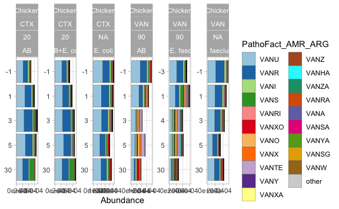

```r
#
# # Plot them side by side with the patchwork package.
# patch <- patchwork::wrap_plots(plot_list, nrow = 1, guides = "collect")
# patch & coord_flip() # make all plots horizontal (note: use & instead of +)
#



p2 + facet_wrap(Model ~ Antibiotic + Antibiotic_mg.mL + Treatment2, scales = "free", ncol = 6, nrow = 4) -> p2_1

p2_1
```

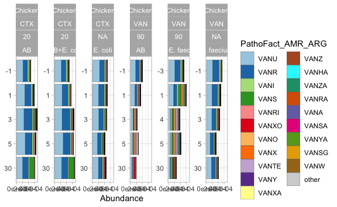

```r
p2 + facet_wrap(Model ~ Antibiotic + Antibiotic_mg.mL + Treatment2, scales = "free_y", ncol = 6, nrow = 4) -> p2_2

p2_2
```

```r
p2_1 %>%
  ggsave(plot = .,bg = "transparent",scale = 2,
         units = "mm",
         dpi = 600,
         height = 0.618 * 84 * 2,
         width = 84 * 2,
         filename = "~/Desktop/glyco_1-1.eps")

p2_2 %>%
  ggsave(plot = .,bg = "transparent",scale = 2,
         units = "mm",
         dpi = 600,
         height = 0.618 * 84 * 2,
         width = 84 * 2,
         filename = "~/Desktop/glyco_1-2.eps")


p2_1 %>%
  export::graph2ppt(append = TRUE, width = 317.48031496 * 2  , height = 0.618 * 317.48031496 * 0.75 , paper = "A4",  scaling = 2,
                    file = out_pptx)
```

```
## Exported graph as ~/Desktop/plots_manuscript_chicken1.pptx
```

```r
p2_2 %>%
  export::graph2ppt(append = TRUE, width = 317.48031496 * 2  , height = 0.618 * 317.48031496 * 0.75 , paper = "A4",  scaling = 2,
                    file = out_pptx)
```

```
## Exported graph as ~/Desktop/plots_manuscript_chicken1.pptx
```

- cephalosporin:

```r
ps_AMR_all %>%
  physeq_sel_tax_table(c("PathoFact_AMR_AMR_sub_class", "PathoFact_AMR_AMR_sub_class_multi", "PathoFact_AMR_ARG", "PathoFact_AMR_MGE_prediction_clean_2"))  %>%
  prune_samples(samples, .) %>%
  physeq_add_metadata(metadata_mapping,
                      sample_column = "sample_id") %>%
  subset_taxa(PathoFact_AMR_AMR_sub_class_multi %in% c("cephalosporin")) %>%
  filter_taxa(function(x) sum(x > 0) > 0, TRUE) -> ps_tmp

ps_tmp %>%
  tax_table() %>%
  data.frame() %>%
  mutate(PathoFact_AMR_MGE_prediction_clean_2 = case_when(grepl("ambiguous", PathoFact_AMR_MGE_prediction_clean_2) ~ "ambiguous", TRUE ~ PathoFact_AMR_MGE_prediction_clean_2)) %>%
  # mutate(PathoFact_AMR_MGE_prediction_clean_2 = case_when(PathoFact_AMR_MGE_prediction_clean_2 %in% c("MAG", "chromosome")  ~ "MAG - chromosome", TRUE ~ PathoFact_AMR_MGE_prediction_clean_2)) %>%
  mutate(PathoFact_AMR_MGE_prediction_clean_2 = fct_relevel(PathoFact_AMR_MGE_prediction_clean_2, c("MAG", "chromosome", "plasmid", "phage", "ambiguous", "unclassified"))) %>%
  as.matrix() -> tax_table(ps_tmp)
```

```r
ps_tmp %>%
  ps_arrange(-Day_of_Treatment) %>%
  comp_barplot(
    tax_transform_for_plot = "identity",
    tax_level = "PathoFact_AMR_ARG",
    label = "Day_of_Treatment", # name an alternative variable to label axes
    n_taxa = 20, # give more taxa unique colours
    merge_other = FALSE, # split the "other" category to display alpha diversity
    bar_width = 0.9, # reduce the bar width to 70% of one row
    bar_outline_colour = "grey5",
    sample_order = "default") +#,# is the default (use NA to remove outlines)
  # facet_by = c("Model", "Antibiotic", "Antibiotic_mg.mL", "Treatment2")) +
  # group_by = c("Model", "Antibiotic", "Antibiotic_mg.mL", "Treatment2"))
  coord_flip() +  theme_light() +
  scale_y_continuous(labels=scientific) -> p2
```

```
## Short values detected in phyloseq tax_table (nchar<4) :
## Consider using tax_fix() to make taxa uniquely identifiable
```

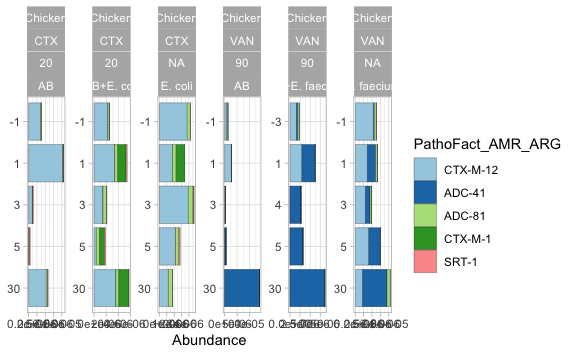

```r
#
# # Plot them side by side with the patchwork package.
# patch <- patchwork::wrap_plots(plot_list, nrow = 1, guides = "collect")
# patch & coord_flip() # make all plots horizontal (note: use & instead of +)
#



p2 + facet_wrap(Model ~ Antibiotic + Antibiotic_mg.mL + Treatment2, scales = "free", ncol = 6, nrow = 4) -> p2_1

p2_1
```

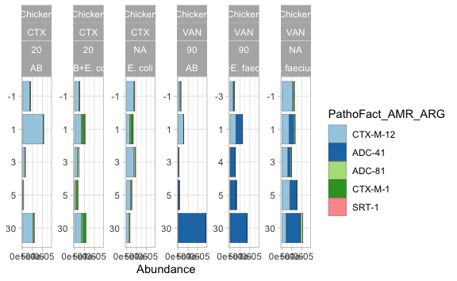

```r
p2 + facet_wrap(Model ~ Antibiotic + Antibiotic_mg.mL + Treatment2, scales = "free_y", ncol = 6, nrow = 4) -> p2_2

p2_2
```

```r
p2_1 %>%
  ggsave(plot = .,bg = "transparent",scale = 2,
         units = "mm",
         dpi = 600,
         height = 0.618 * 84 * 2,
         width = 84 * 2,
         filename = "~/Desktop/cephalosporin_1-1.eps")

p2_2 %>%
  ggsave(plot = .,bg = "transparent",scale = 2,
         units = "mm",
         dpi = 600,
         height = 0.618 * 84 * 2,
         width = 84 * 2,
         filename = "~/Desktop/cephalosporin_1-2.eps")


p2_1 %>%
  export::graph2ppt(append = TRUE, width = 317.48031496 * 2  , height = 0.618 * 317.48031496 * 0.75 , paper = "A4",  scaling = 2,
                    file = out_pptx)
```

```
## Exported graph as ~/Desktop/plots_manuscript_chicken1.pptx
```

```r
p2_2 %>%
  export::graph2ppt(append = TRUE, width = 317.48031496 * 2  , height = 0.618 * 317.48031496 * 0.75 , paper = "A4",  scaling = 2,
                    file = out_pptx)
```

```
## Exported graph as ~/Desktop/plots_manuscript_chicken1.pptx
```

- VANA

```r
ps_AMR_all %>%
  physeq_sel_tax_table(c("PathoFact_AMR_AMR_sub_class", "PathoFact_AMR_AMR_sub_class_multi", "PathoFact_AMR_MGE_prediction_clean_2", "PathoFact_AMR_ARG"))  %>%
  prune_samples(samples, .) %>%
  physeq_add_metadata(metadata_mapping,
                      sample_column = "sample_id") %>%
  subset_taxa(PathoFact_AMR_ARG %in% c("VANA")) %>%
  filter_taxa(function(x) sum(x > 0) > 0, TRUE) -> ps_tmp

ps_tmp %>%
  tax_table() %>%
  data.frame() %>%
  rownames_to_column('GN_id') %>%
  mutate(PathoFact_AMR_MGE_prediction_clean_2 = case_when(grepl("ambiguous", PathoFact_AMR_MGE_prediction_clean_2) ~ "ambiguous", TRUE ~ PathoFact_AMR_MGE_prediction_clean_2)) %>%
  # mutate(PathoFact_AMR_MGE_prediction_clean_2 = case_when(PathoFact_AMR_MGE_prediction_clean_2 %in% c("MAG", "chromosome")  ~ "MAG - chromosome", TRUE ~ PathoFact_AMR_MGE_prediction_clean_2)) %>%
  mutate(PathoFact_AMR_MGE_prediction_clean_2 = fct_relevel(PathoFact_AMR_MGE_prediction_clean_2, c("MAG", "chromosome", "plasmid", "phage", "ambiguous", "unclassified"))) %>%
  mutate(GN = paste(GN_id, PathoFact_AMR_MGE_prediction_clean_2, PathoFact_AMR_ARG, sep  = "_")) %>%
  column_to_rownames("GN_id") %>%
  as.matrix() -> tax_table(ps_tmp)

ps_tmp %>%
  tax_filter(undetected = 0, use_counts = FALSE) %>%
  # microViz::phyloseq_validate(use_counts = FALSE) %>%
  microViz::ps_arrange(-Day_of_Treatment) %>%
  microViz::comp_barplot(
    tax_transform_for_plot = "identity",
    tax_level = "GN",
    label = "Day_of_Treatment", # name an alternative variable to label axes
    n_taxa = 15, # give more taxa unique colours
    merge_other = FALSE, # split the "other" category to display alpha diversity
    bar_width = 0.9, # reduce the bar width to 70% of one row
    bar_outline_colour = "grey5",
    sample_order = "default") +#,# is the default (use NA to remove outlines)
  # facet_by = c("Model", "Antibiotic", "Antibiotic_mg.mL", "Treatment2")) +
  # group_by = c("Model", "Antibiotic", "Antibiotic_mg.mL", "Treatment2"))
  coord_flip() +  theme_light() +
  scale_y_continuous(labels=percent) -> p2


p2 + facet_wrap(Model ~ Antibiotic + Antibiotic_mg.mL + Treatment2, scales = "free", ncol = 6, nrow = 4) -> p2_1

p2_1

p2 + facet_wrap(Model ~ Antibiotic + Antibiotic_mg.mL + Treatment2, scales = "free_y", ncol = 6, nrow = 4) -> p2_2

p2_2

p2_1 %>%
  ggsave(plot = .,bg = "transparent",scale = 2,
         units = "mm",
         dpi = 600,
         height = 0.618 * 84 * 2,
         width = 84 * 2,
         filename = "~/Desktop/vana_2-1.eps")

p2_2 %>%
  ggsave(plot = .,bg = "transparent",scale = 2,
         units = "mm",
         dpi = 600,
         height = 0.618 * 84 * 2,
         width = 84 * 2,
         filename = "~/Desktop/vana_2-2.eps")


p2_1 %>%
  export::graph2ppt(append = TRUE, width = 317.48031496 * 2  , height = 0.618 * 317.48031496 * 0.75 , paper = "A4",  scaling = 2,
                    file = out_pptx)

p2_2 %>%
  export::graph2ppt(append = TRUE, width = 317.48031496 * 2  , height = 0.618 * 317.48031496 * 0.75 , paper = "A4",  scaling = 2,
                    file = out_pptx)
```

- CTX-M-1

```r
# ps_AMR_all %>%
#   physeq_sel_tax_table(c("PathoFact_AMR_AMR_sub_class", "PathoFact_AMR_AMR_sub_class_multi", "PathoFact_AMR_MGE_prediction_clean_2", "PathoFact_AMR_ARG"))  %>%
#   prune_samples(samples, .) %>%
#   physeq_add_metadata(metadata_mapping,
#                       sample_column = "sample_id") %>%
#   subset_taxa(PathoFact_AMR_ARG %in% c("CTX-M-1")) %>%
#   filter_taxa(function(x) sum(x > 0) > 0, TRUE) -> ps_tmp
#
# ps_tmp %>%
#   tax_table() %>%
#   data.frame() %>%
#   rownames_to_column('GN_id') %>%
#   mutate(PathoFact_AMR_MGE_prediction_clean_2 = case_when(grepl("ambiguous", PathoFact_AMR_MGE_prediction_clean_2) ~ "ambiguous", TRUE ~ PathoFact_AMR_MGE_prediction_clean_2)) %>%
#   # mutate(PathoFact_AMR_MGE_prediction_clean_2 = case_when(PathoFact_AMR_MGE_prediction_clean_2 %in% c("MAG", "chromosome")  ~ "MAG - chromosome", TRUE ~ PathoFact_AMR_MGE_prediction_clean_2)) %>%
#   mutate(PathoFact_AMR_MGE_prediction_clean_2 = fct_relevel(PathoFact_AMR_MGE_prediction_clean_2, c("MAG", "chromosome", "plasmid", "phage", "ambiguous", "unclassified"))) %>%
#   mutate(GN = paste(GN_id, PathoFact_AMR_MGE_prediction_clean_2, PathoFact_AMR_ARG, sep  = "_")) %>%
#   column_to_rownames("GN_id") %>%
#   as.matrix() -> tax_table(ps_tmp)
#
# ps_tmp %>%
#   ps_arrange(-Day_of_Treatment) %>%
#   comp_barplot(
#     tax_transform_for_plot = "identity",
#     tax_level = "GN",
#     label = "Day_of_Treatment", # name an alternative variable to label axes
#     n_taxa = 18, # give more taxa unique colours
#     merge_other = FALSE, # split the "other" category to display alpha diversity
#     bar_width = 0.9, # reduce the bar width to 70% of one row
#     bar_outline_colour = "grey5",
#     sample_order = "default") +#,# is the default (use NA to remove outlines)
#   # facet_by = c("Model", "Antibiotic", "Antibiotic_mg.mL", "Treatment2")) +
#   # group_by = c("Model", "Antibiotic", "Antibiotic_mg.mL", "Treatment2"))
#   coord_flip() +  theme_light() +
#   scale_y_continuous(labels=scientific) -> p2
# #
# # # Plot them side by side with the patchwork package.
# # patch <- patchwork::wrap_plots(plot_list, nrow = 1, guides = "collect")
# # patch & coord_flip() # make all plots horizontal (note: use & instead of +)
# #
#
# p2 + facet_wrap(Model ~ Antibiotic + Antibiotic_mg.mL + Treatment2, scales = "free", ncol = 6, nrow = 4) -> p2_1
#
# p2_1
#
# p2 + facet_wrap(Model ~ Antibiotic + Antibiotic_mg.mL + Treatment2, scales = "free_y", ncol = 6, nrow = 4) -> p2_2
#
# p2_2
#
# p2_1 %>%
#   ggsave(plot = .,bg = "transparent",scale = 2,
#          units = "mm",
#          dpi = 600,
#          height = 0.618 * 84 * 2,
#          width = 84 * 2,
#          filename = "~/Desktop/CTX_1.eps")
#
# p2_2 %>%
#   ggsave(plot = .,bg = "transparent",scale = 2,
#          units = "mm",
#          dpi = 600,
#          height = 0.618 * 84 * 2,
#          width = 84 * 2,
#          filename = "~/Desktop/CTX_2.eps")
#
#
# p2_1 %>%
#   export::graph2ppt(append = TRUE, width = 317.48031496 * 2  , height = 0.618 * 317.48031496 * 0.75 , paper = "A4",  scaling = 2,
#                     file = out_pptx)
#
# p2_2 %>%
#   export::graph2ppt(append = TRUE, width = 317.48031496 * 2  , height = 0.618 * 317.48031496 * 0.75 , paper = "A4",  scaling = 2,
#                     file = out_pptx)
```

HQ MAG contributors:

```r
ps_AMR_all %>%
  physeq_sel_tax_table(c("PathoFact_AMR_AMR_sub_class", "PathoFact_AMR_AMR_sub_class_multi", "PathoFact_AMR_MGE_prediction_clean_2", "ANVIO_CONCOCT_HQ_clean", "CONCOCT_bin",
                         "GTDB_tax_CONCOCT_clean" ,"PathoFact_AMR_ARG")) %>%
  prune_samples(samples, .) %>%
  physeq_add_metadata(metadata_mapping,
                      sample_column = "sample_id") %>%
  # subset_taxa(!is.na("GTDB_tax_CONCOCT_clean")) %>%
  # physeq_sel_tax_table(c("PathoFact_AMR_ARG"))  %>%
  speedyseq::tax_glom(., taxrank = "GTDB_tax_CONCOCT_clean")  %>%
  filter_taxa(function(x) sum(x > 0) > 0, TRUE) %>%
  microbiome::transform("compositional") %>%
  speedyseq::psmelt() %>%
  separate(GTDB_tax_CONCOCT_clean, into = c("domain", "phylum", "class", "order", "family", "genus", "species"), sep  = ";" , remove = FALSE) -> df
```

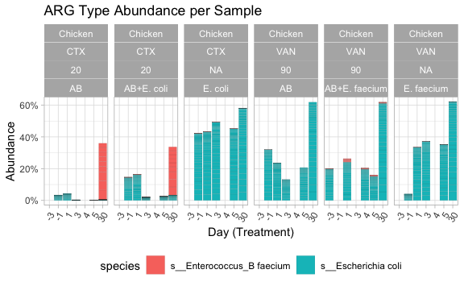

```r
df %>%
  filter(genus %in% c("g__Enterococcus_B",
                      "g__Escherichia")) %>%
  mutate(Abundance = na_if(Abundance, 0)) %>%
  mutate(logTPM = log10(Abundance + 1))  %>%
  # separate_rows(., Resistance_Mechanism,sep = '; ',convert = TRUE) %>%
  # ggplot(aes(x = as.factor(Day_of_Treatment), y = Abundance, fill = fct_reorder(Strain, logTPM))) +
  ggplot(aes(x = as.factor(Day_of_Treatment), y = Abundance, fill = species)) +#reorder(genus, Abundance, FUN=median, na.rm = TRUE))) +
  geom_bar( stat = "identity", colour="black", size=0.025) +
  facet_wrap(Model ~ Antibiotic + Antibiotic_mg.mL + Treatment2, scales = "fixed", ncol = 6, nrow = 4) +
  # facet_grid(Model ~ Treatment + Fermentation + Antibiotic_mg.mL , scales = "free", space = "free_x", drop = TRUE) +
  ggtitle("ARG Type Abundance per Sample") +
  xlab("Day (Treatment)")  +
  # ylab("Proportion") +
  theme_light() +
  scale_y_continuous(labels=percent) +
  # scale_fill_manual(name = "", values = col_strains) +
  theme(legend.position = "bottom") +
  ggpubr::rotate_x_text(60) +
  theme(legend.position = ("bottom")) -> p_mec

# p_mec %>%
#   ggpubr::set_palette("jco") -> p_mec

p_mec
```

```r
p_mec %>%
  export::graph2ppt(append = TRUE, width = 317.48031496 * 2  , height = 0.618 * 317.48031496 * 0.75 , paper = "A4",  scaling = 2,
                    file = out_pptx)
```

```
## Exported graph as ~/Desktop/plots_manuscript_chicken1.pptx
```

Need to clarify resistome contributors since some gene are assigned to bins but are lacking GTDB taxonomy. updated collection?

contigs of interest: c1_megahit_8588 c1_megahit_219391

- the top gene -> where line plot facet localisation? heatmap?
- heatmap AMR class + genetic material + dendro
- heatmap AMR GN + dendro

Resistome Proportion AMR categories Gene heatmap Diversity: alpha/beta Contributing genetic material (MAGs/Chromosomes/plasmids/…) Number of AMR/ contigs / plasmids – length Number of unmapped reads / sample Prop/coverage or whatsoever per gene per mag per sample (rector/time) Visualise contigs with ARG in anvo -> coverage variability.

proof of concept with WAFLE METACHIP proof of concept ANVIO -> population variability

MAG resistome? donor strain chromosomal resistome?